# Seeking surrogates for taxonomic and functional evaluations of leaf-litter ant faunas - ScienceDirect

## [Ecological Indicators](https://www.sciencedirect.com/science/journal/1470160X)

[Volume 122](https://www.sciencedirect.com/science/journal/1470160X/122/supp/C), March 2021, 107305

# Seeking surrogates for taxonomic and functional evaluations of leaf-litter ant faunas

[Elmo B.A.Koch<sup>a</sup>](https://www.sciencedirect.com/science/article/pii/S1470160X20312474?fbclid=IwAR2Y0D1FB5eKXRRjgbeXUTVO51FlxKbZvJxIAaSfXws4QUiAEuaMjQn-_d8#!)[Ivan CardosoNascimento<sup>b</sup>](https://www.sciencedirect.com/science/article/pii/S1470160X20312474?fbclid=IwAR2Y0D1FB5eKXRRjgbeXUTVO51FlxKbZvJxIAaSfXws4QUiAEuaMjQn-_d8#!)[Jonathan D.Majer<sup>c</sup><sup>d</sup>](https://www.sciencedirect.com/science/article/pii/S1470160X20312474?fbclid=IwAR2Y0D1FB5eKXRRjgbeXUTVO51FlxKbZvJxIAaSfXws4QUiAEuaMjQn-_d8#!)[Jacques H.C.Delabie<sup>a</sup><sup>e</sup>](https://www.sciencedirect.com/science/article/pii/S1470160X20312474?fbclid=IwAR2Y0D1FB5eKXRRjgbeXUTVO51FlxKbZvJxIAaSfXws4QUiAEuaMjQn-_d8#!)

https://doi.org/10.1016/j.ecolind.2020.107305[Get rights and content](https://s100.copyright.com/AppDispatchServlet?publisherName=ELS&contentID=S1470160X20312474&orderBeanReset=true)

Under a Creative Commons [license](https://creativecommons.org/licenses/by/4.0/)

open access

## Highlights

**•**

Biodiversity surrogates provide meaningful information at a lower cost and effort.

**•**

Ants are often used in such environmental assessments.

**•**

We seek a useable substitute surrogate for taxonomic and functional ant diversity.

**•**

For this, we tested four potential ant surrogates at 65 Atlantic rainforest sites.

**•**

Of the species and functional group surrogates, mixed-level was the best.

## Abstract

Comprehensive biodiversity inventories are expensive and time-consuming to achieve, especially for groups of megadiverse organisms. One approach to resolve such situations is to utilize biological substitutes, referred to as surrogates. A surrogate should provide meaningful information at a lower cost and/or effort than the original level of resolution. Studies have shown that species richness is often not the best or most appropriate component or predictor of biodiversity. Functional diversity can be used as a measurement of the ecological differentiation between habitats or between biological functions. We evaluated the use of several taxonomic metrics as potential surrogates for leaf-litter ant assemblages distributed in 65 Atlantic rainforest sites. Our goal was to find reliable and economic substitutes for both taxonomic and functional leaf-litter ant diversity and composition. We tested four potential surrogate approaches for taxonomic metrics and three for functional group metrics. Additionally, we also evaluated the time and costs involved. We used a large leaf-litter ant database that comprises 364 ant species, respectively classified into 13 or 26 ant functional groups based on either a general and specific resolution. Subfamily was found to be an unacceptable surrogate for both taxonomic and functional group metrics. Mixed-level and indicator taxa metrics were rated as ‘excellent’ taxonomic surrogates. Mixed-level and genus metrics were rated as ‘excellent’ or ‘acceptable’ functional group surrogates when considering the most general functional resolution, while mixed-level and genus were considered as ‘excellent’ surrogates when considering the more specific resolution. The monetary and time costs to identify ants to genus level were lower than those using indicator taxa and mixed-level metrics. The use of a certain higher taxon functional and taxonomic surrogates allows a reduction of survey and analysis costs while still enabling the analysis of biological diversity from the taxonomic and functional point of view.

## Keywords

Biodiversity

Taxonomic sufficiency

Formicidae

Atlantic rainforest

Functional groups

Economic assessment

## 1. Introduction

Exploring patterns of diversity have been one of the main challenges in community ecology (Pianka, 1966, Hawkins, 2001, Agrawal et al., 2007), while conserving diversity is the main goal of conservation biology (Myers et al., 2000, Wallington et al., 2005, Moore et al., 2009). However, comprehensive biodiversity inventories are expensive, time-consuming, and almost impossible to conclude satisfactorily (Whittaker et al., 2005). This is particularly so for groups of megadiverse organisms and those for which taxonomic knowledge is still lacking. The choice of biological groups used in diversity studies and environmental assessments has particularly been influenced by taxonomic impediments and by the diminishing number of salaried taxonomists who are able to describe and assist in identification of species (Basset et al., 2004). For terrestrial invertebrates, this deficiency has been a factor that has hindered the inclusion of these groups in conservation and bioindication research (Kallimanis et al., 2012). Because of this, there has been an increasing interest in finding more rapid and efficient biodiversity monitoring techniques (Groc et al., 2010, Mandelik et al., 2010, Kessler et al., 2011).

One approach that is increasingly being used to circumvent this problem is the use of biological substitutes, or “surrogates” of biological diversity. A surrogate can be a subset of species that is indicative of the presence of all species (Gaston, 1996). It can be a higher taxonomic level, such as family or genus (Ellis, 1985, Williams and Gaston, 1994, de Oliveira et al., 2020), the use of morphospecies as an alternative to the use of species to describe community structure (Oliver and Beattie, 1996a, Oliver and Beattie, 1996b, Pik et al., 1999), or groups of species that are capable of representing responses to environmental conditions by other taxa (Sarkar and Margules, 2002, Landeiro et al., 2012). The ideal surrogate should provide meaningful information about the environment in which it occurs at a lower cost or effort than would be required to sort and identify fauna at the species level (Ellis, 1985); ideally, it should also require less taxonomic expertise (Morrison et al., 2012). Obtaining a good surrogate allows practitioners to analyze biological diversity while at the same time minimizing the costs and time associated with accurate taxonomic analysis (Grimbacher et al., 2008). According to Williams and Gaston (1994), achieving this taxonomic independence could contribute to reducing the large load of identification by taxonomists, thus allowing more investment in systematic studies and the allocation of more resources for temporal or spatial replications of studies (Grimbacher et al., 2008).

Species, taxonomic units, or groups of species that can be used to measure some characteristic of the environment are regarded as biological indicators, generally referred to as bioindicators (McGeogh, 1998). These taxa can act as a bioindicator when responding/representing the biotic or abiotic state of an environment and/or they can indicate the diversity of a set of species or a biological group. As such, they can represent the impact of environmental conditions or pollution in a habitat (McGeoch, 2007). Among terrestrial invertebrates, ants (Formicidae) are a globally dominant group that are frequently used in environmental monitoring and evaluation studies (Andersen and Majer, 2004, Underwood and Fisher, 2006, Delabie et al., 2009, Guzmán-Mendoza et al., 2016). This is mainly due to their ecological dominance (Hölldobler and Wilson, 1990), their intimate relationship with the environment (Kaspari and Majer, 2000), their influence on the diversity of other groups (Izzo and Vasconcelos, 2005, Philpott and Armbrecht, 2006), their predictable response to environmental disturbances (Andersen and Majer, 2004, Agosti and Alonso, 2000, Delabie et al., 2009, Andersen, 2019), their role in important ecological functions (Folgarait, 1998, Hoffmann and Andersen, 2003, Crist, 2009, Bihn et al., 2010) and the fact that this diverse group can be easily sampled by methods that are easy to reproduce (Folgarait, 1998, Delabie et al., 2021).

In recent years, a considerable and growing number of studies have investigated suitable surrogates for the richness and composition of ant assemblages (Andersen, 1995, Leal et al., 2010, Groc et al., 2010, Gutiérrez et al., 2017, Souza et al., 2016). Initially, these studies focused on the use of higher taxonomic levels, such as subfamily and genus (see Andersen, 1995, Andersen et al., 2002), levels that are generally well defined and which can be identified through widely available identification keys. Some studies have also shown that the use of morphospecies, which can be identified in less time and with minimal training in taxonomy (Oliver and Beattie, 1993, Oliver and Beattie, 1997, Beattie and Oliver, 1994), is an adequate substitute for species-level identifications (Oliver and Beattie, 1996a, Oliver and Beattie, 1996b, Pik et al., 1999). Recently, other metrics that allow non-specialists in the taxonomic groups concerned to incorporate these organisms in their own studies (Souza et al., 2016) have been developed. These include the use of indicator taxa - species from genera that meet certain pre-established criteria (generally that are widespread, diverse and identifiable) and are considered representative of the entire assemblage (details in Lawton et al., 1998, McGeogh, 1998, Lindenmayer and Likens, 2011), as well as the use of mixed-level surrogates - a non-hierarchical metric that considers the most specific level of identification possible for species of indicator genera, with the rest of the ant assemblage (of the genera that do not meet the indicator taxa criteria) only being considered up to the level of genus (details in Groc et al., 2010). However, all these studies have as a common objective of evaluating possible surrogates of ant taxonomic metrics, ignoring the functional approach.

Studies have shown that species richness is often not the best, or most appropriate component or predictor of biodiversity (Cadotte et al., 2011, Haines-Young, 2013), since the loss of species or changes in the composition does not necessarily result in the loss of ecosystem functions and processes (Hooper et al., 2005). Nowadays, fewer studies assess the role of species richness alone (Dalerum et al., 2012), and increasingly functional aspects are incorporated in order to complement the traditional taxonomic indicators (Moretti et al., 2009, Gerisch et al., 2012). Functional diversity is considered to be one of the fundamental components of biological diversity (Tilman, 2001) and can be used as a measurement of the ecological differentiation between habits or between biological functions (De Bello et al., 2010, Thompson et al., 2010). As a tool, functional diversity evaluates the various ways in which organisms respond to environmental variability (Gerisch et al., 2012), and may reflect relevant components associated with patterns in the community (De Bello et al., 2010). Functional diversity is generally measured to determine how different species affect the functioning of the ecosystem through the time and space (Petchey and Gaston, 2006). Using species characteristics, it is possible to infer about the functional role of these species in the community (Díaz et al., 2013). These characteristics - functional attributes/traits - can be classified as a response, when they respond to certain environmental changes, or they can be classified as an effect, when they are related to ecosystem characteristics (Chapin et al., 2000, Lavorel and Garnier, 2002, Díaz et al., 2013). Traits at the individual level are generally used to evaluate effect, while morphological or behavioral traits in response to abiotic or biotic factors are more used to assess response (Chapin et al., 2000, Lavorel and Garnier, 2002). The use of these functional attributes allows practitioners to evaluate fundamental dimensions of biodiversity in a simplified, comprehensive and usefully predictive way (Podgaiski et al., 2011).

Studies have shown a clear association between morphology, ecology and taxonomy (Price, 1991, Douglas and Matthews, 1992, Silva and Brandão, 2010). The morphology of an organism can reflect its habitat and its function within an environment (Sosiak and Barden, 2020). The use of functional groups reveals sets of sympatric species occupying niches or similar ecological roles, these being organisms that influence the environment together and in a similar way (Wilson, 1999, Philpott et al., 2009). Over the years researchers on ants from the Neotropical region have proposed classifications of functional groups that consider morphology, trophic characteristics, micro-habitat distribution (vertical stratification of fauna), biology and life styles (Delabie et al., 2000, Silva and Brandão, 2010, Brandão et al., 2012, Koch et al., 2019). The use of such schemes simplifies the ecological complexity of the situation and allows comparative analyses (Philpott et al., 2009).

In this study, we evaluated and compared the use and performance of different metrics as potential surrogates of leaf-litter ant diversity in the Atlantic rainforest throughout the Brazilian state of Bahia. We tested four potential surrogates for ant assemblages, by considering the composition and number of species, as well as the composition and number of functional groups of ants at two functional group (FG) resolutions. Our goal was to find a reliable, economic and effective substitute for the direct measurement of taxonomic and functional leaf-litter ant diversities. We hypothesized that: (i) at the species level the best substitute may be genus; (ii) at the FG level, the best substitute may be a mixed-level; and (iii) genus will be the best substitute when considering time and monetary savings. These results were expected since previous studies have shown that genus is an excellent substitute for species level determinations in different environments (Pik et al., 1999, Heino and Soininen, 2007, Gallego et al., 2012, Souza et al., 2016, Gutiérrez et al., 2017, de Oliveira et al., 2020). By contrast, we expected that functional diversity could provide a different outcome than for taxonomic diversity, since studies have shown a positive linear relationship between taxonomic and functional diversity (Bihn et al., 2010, Rocha-Ortega et al., 2018). In addition, the functional role of some of the species within any given genus may differ in their role within the ecosystem (Koch et al., 2019).

## 2. Materials and methods

### 2.1. Study region and ant sampling design

We used the same large leaf-litter ant database that was used for the study of Koch et al. (2019). The ants were collected in 65 Atlantic rainforest sites in the southern region of the state of Bahia, Brazil (Fig. 1). The region covers an area of 6500 km<sup>2</sup> (130 × 50 km) of Atlantic rainforest. This formation belongs to the tropical wet forest biome and is considered one of the most threatened tropical biomes on the world, being one of the World’s major hotspots of terrestrial biodiversity (Mittermeier et al., 1998, Myers, 1988, Myers et al., 2000).

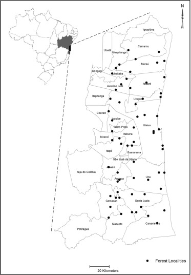

1. [Download : Download high-res image (204KB)](https://ars.els-cdn.com/content/image/1-s2.0-S1470160X20312474-gr1_lrg.jpg)
2. [Download : Download full-size image](https://ars.els-cdn.com/content/image/1-s2.0-S1470160X20312474-gr1.jpg)

Fig. 1. Positions of the 65 Atlantic rainforest ant sample sites in the state of Bahia, Brazil.

For the sampling of ants, an adaptation of the ALL protocol was used (Agosti and Alonso, 2000). One transect of approximately 2500 m was established in each site, along each transect 50 sampling points (at intervals of 50 m) were marked out. At each point, the ants living in 1 m<sup>2</sup> of leaf litter were extracted using Winkler traps (Bestelmeyer et al., 2000, Delabie et al., 2021). A total of 50 leaf litter samples were sampled per site. The samples remained in the Winkler extractors for 48 h. Then, the ants were separated from the other arthropods, mounted and identified to the most specific level possible, based on the Formicidae reference collection at the Myrmecology Laboratory of the Cocoa Research Center and by consulting the relevant literature (e.g., Bolton et al., 2007).

### 2.2. Taxonomic surrogate metrics

To evaluate the various metrics as possible surrogates for ant species/morphospecies (hereafter referred to as species), we reduced the taxonomic resolution by classifying ants to: (i) the level of subfamily; (ii) genus; and (iii) a selected subset of genera that could be considered as indicator taxa (details in Lawton et al., 1998, Lindenmayer and Likens, 2011). The latter were based on the presupposition that certain genera could be good substitutes of all ant species within certain environments (Andersen, 1995). We considered indicator taxa to be those genera that met the following criteria, namely that: (a) the indicator must have at least one species present in a minimum of 50 of 65 sampling sites; (b) it must have at least seven species in all site data grouped; and (c) it must be taxonomically well defined. Of the 68 genera obtained in the database, those that meet the established criteria were *Apterostigma*, *Brachymyrmex*, *Cyphomyrmex*, *Gnamptogenys*, *Hypoponera*, *Megalomyrmex*, *Neoponera*, *Nylanderia*, *Pheidole*, *Rogeria*, *Solenopsis* and *Strumigenys* (see Table S1 in Supporting information). Finally, (iv) we tested the mixed-level metric proposed by Groc et al. (2010). This combines two different levels of identification, with part of the assemblage identified to species level (i.e. all members of the 12 indicator genera) and the remaining part identified to genus level.

### 2.3. Functional surrogates: Ant functional group resolutions

Except for the subfamily level, the same potential surrogate levels were also tested as predictors of the number of FGs found per site. We did not consider the subfamily level because the variation in ecological functions amongst taxa is too varied within a subfamily. For functional surrogates, the analyses were performed using two different FG resolutions, one more general and one more specific (details below).

### 2.4. Assessment of time and money costs

Although the sampling of ants is relatively easy to carry out, the costs and time spent are a necessary consideration (e.g. Majer et al., 2007, Souza et al., 2012). We therefore assessed the time and money costs involved in the four surrogate metrics. These assessments were performed according to Souza et al. (2016), by which we calculated the time taken and monetary costs associated with each surrogate. Costs were based on basic staff charges, materials, and ant sampling costs. According to Gardner et al. (2008), costs of accommodation buildings and laboratory equipment and for the field team are fixed costs for all procedures, so we did not consider them. All costs were estimated for each site, with the rates being based on current (2020) Brazilian Federal Government costing tables (available at https://www.bcb.gov.br/estabilidadefinanceira/historicocotacoes). First, we consider costs considering the value of the currency during the time that the material was processed and corrected for current inflation. We converted the Brazilian currency (Real = R$) to US dollars using the conversion rate: 1 US$ = R$ 4.06 (daily averages between the months of March 2019 to February 2020; source: Brazilian Central Bank; https://www.bcb.gov.br/). For each forest site we calculated the time and monetary costs to obtain the number of registered species (i.e. processing and identification). Then, to obtain the value for each potential surrogate, we divided the total money and time spent by the number of units of surrogate resolutions in a given site.

### 2.5. Statistical analysis

The surrogate was considered to be: 'excellent' if it predicted (based on r or *r*<sup>2</sup> values obtained) ≥80% of variation found in the actual species level data; 'good' if it predicted ≥70% and <80% of variation; 'acceptable' if it predicted ≥60% and <70% of variation; and 'not acceptable' if it predicted <60% of variation. These values were originally proposed by Leal et al. (2010) for predictions of taxonomic diversity by substitutes, although we adapted its use for our study and expanded it to functional diversity of ants.

#### 2.5.1. Surrogates for assemblage composition and functional group composition

For each site and considering all 50 points, a fully-resolved taxonomic spreadsheet, based on ant species and morphospecies, was used to produce taxonomic spreadsheet at two levels - genus and subfamily. Additionally, as already detailed, we also organized the spreadsheet to consider the indicator taxa and mixed-level resolutions. Thus, five pages of spreadsheets were constructed for each site.

Then we calculate a distance matrix for each different spreadsheet. We used the Jaccard index (Rohlf, 1989), one of the similarity indices most used to assess the compositional similarity of species assemblages (Manthey and Fridley, 2009). We focused on beta diversity in this study. Sample-by-taxon matrices are recommended to compare measures of beta diversity among groups of samples (Groc et al., 2010). Beta diversity is often measured using indices of species overlapping between pairs of samples. We used the Mantel test (Mantel, 1967) to correlate the species-distance matrix with that of each different surrogate evaluated (subfamily, genera, indicator taxa and mixed-level values) considering each site. The Mantel test calculates the similarity between two given distance matrices, here using the Pearson correlation method. The statistical significance of the Mantel tests was calculated using 5000 permutations. Subsequently, we evaluated whether there is a difference in how much each matrix of the different surrogate taxa predicted the species matrix (represented by Pearson's correlation coefficients) using an analysis of variance (ANOVA) with repeated measures, followed by the Tukey multiple-range test. In this analysis, the dependent variable was the Mantel correlation coefficient value and the independent variable was the surrogate resolution type, considering the site as a random factor. We used repeated measures ANOVA to consider any possible residual autocorrelation within the sites.

The same analyses were performed considering the composition of functional groups. We subsequently tested how much each matrix of the different metrics predicted the FG matrix using a two-way repeated measures ANOVA. In this analysis, the dependent variable was the Mantel correlation coefficient value and the independent variables were the surrogate resolution type and FG scheme, considering the site as a random factor.

#### 2.5.2. Surrogates for species richness and functional group richness

In order to evaluate whether the number of surrogate taxa is a good predictor of species richness, we compared the number of ant species per site with the number of the surrogate taxa considering the different surrogate levels (number of subfamilies, genera, indicator taxa and mixed-level values per site) using a series of linear regressions (separately for each possible surrogate level). Additionally, we compared the number of ant FGs with the number of the surrogate taxa considering the different surrogate levels (genera, indicator taxa and mixed-level values) also using linear regressions (separately for each possible surrogate level). For these analyses we considered each of the 65 forests sampled sites as the units of analysis.

#### 2.5.3. Assessment of time and monetary costs

We evaluated differences in the relative costs and time taken to obtain the final product according to the metric used, considering that species level classification would be 100%. To assess whether there is a difference in financial costs according to the levels of surrogates tested we used a repeated measures ANOVA, followed by the Tukey multiple-range test. In this analysis, the dependent variable was the financial cost to reach the taxonomic units evaluated for each site, and the independent variable was the surrogate resolution type, considering the site as a random factor. All analyses were performed using the software R v. 3.6.1 (R Development Core Team, 2019). All assumptions of the tests performed were tested and obeyed. The packages “ggplot2” (Wickham, 2016) and “vegan” (Oksanen et al., 2018) were used.

Finally, we produced a table with a summary of the degree of performance of the various surrogates evaluated. For this we considered the prediction values already explained (at the beginning of the data analysis section) and costs. We created an index ranging from 1 to 4, with 1 being the most desirable outcome and 4 the least. We assigned the values = 1 when the surrogate assessed was considered excellent or the best for a given metric tested, 2 when it was considered the second best or most suitable, and so on.

## 3. Results

The database in Table S1 comprises 10 ant subfamilies, representing 68 genera and 364 species. These were classified into 13 FGs under the FC-A scheme and 26 FGs under FC-B. The number of taxonomic units identified as indicator taxa and as mixed-level taxa (i.e. the species of the 12 indicator genera plus the 56 remaining genera no indicator taxa) was 195 and 251, respectively (Table S2).

### 3.1. Taxonomic diversity

#### 3.1.1. Surrogates for assemblage composition

The values of correlations between the species composition matrices and the surrogate composition matrices and p-values for each of the 65 sites are shown in Table S3. All individual correlation coefficients were significant.

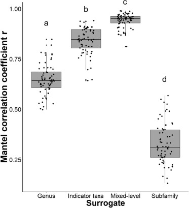

1. [Download : Download high-res image (112KB)](https://ars.els-cdn.com/content/image/1-s2.0-S1470160X20312474-gr2_lrg.jpg)
2. [Download : Download full-size image](https://ars.els-cdn.com/content/image/1-s2.0-S1470160X20312474-gr2.jpg)

Fig. 2. Correlations between dissimilarity in species composition matrices and the dissimilarity in surrogate composition matrices (means ± SD) using the four surrogates. The different letters above the SD bars indicate that all means are significantly different (values are given in Table S3).

#### 3.1.2. Surrogates for species richness

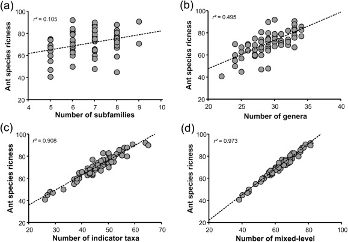

1. [Download : Download high-res image (267KB)](https://ars.els-cdn.com/content/image/1-s2.0-S1470160X20312474-gr3_lrg.jpg)
2. [Download : Download full-size image](https://ars.els-cdn.com/content/image/1-s2.0-S1470160X20312474-gr3.jpg)

Fig. 3. Relationships between the number of ant species and the number of taxa for the four taxonomic surrogates at the 65 study sites. (a) subfamily, (b) genus, (c) indicator taxa, and (d) mixed-level.

### 3.2. Functional group surrogates

#### 3.2.1. Surrogates for functional group composition

The values of Mantel correlation coefficients for each of the 65 sites for comparisons between matrices of functional ant composition with the various surrogate schemes are shown in Table S4. All but one of the individual correlation coefficients were significant (*P* < 0.05).

We observed significant differences in the Mantel correlation coefficients for FGs versus the various surrogates (*F*<sub>2,128</sub> = 588.8, *P* < 0.001) (Fig. 4). In the pairwise Tukey’s test we observed that indicator taxa showed lower average correlation coefficients when compared to genus and mixed-level (Tukey, *P* < 0.001). Overall, we found a significant difference between the type of FG resolution used (*F*<sub>1,192</sub> = 15. 32, *P* = 0.001). However, we also found a significant interaction between surrogate type and the FG resolution level used (*F*<sub>2,192</sub> = 13.98, *P* < 0.001). This was because this difference was dependent on surrogate used, being significant only for indicator taxa (*F*<sub>1,129</sub> = -3.019, *P* = 0.003) (Fig. 4). The highest correlations with FG-level resolutions were for genus (mean = 1.000 ± SD 0.000 for FC-A and 1.000 ± 0.000 for FC-B), followed by the mixed-level approach (0.988 ± 0.008 to FC-A; 0.990 ± 0.007 to FC-B); these were both rated as excellent surrogates for FGs. The corresponding correlation for indicator taxa (0.684 ± 0.147 to FC-A; 0.745 ± 0.064 to FC-B) indicated that this was considered as an acceptable surrogate for FG composition using FC-A and good using FC-B.

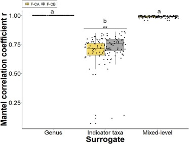

1. [Download : Download high-res image (96KB)](https://ars.els-cdn.com/content/image/1-s2.0-S1470160X20312474-gr4_lrg.jpg)
2. [Download : Download full-size image](https://ars.els-cdn.com/content/image/1-s2.0-S1470160X20312474-gr4.jpg)

Fig. 4. Correlations between dissimilarity in species composition matrices and the dissimilarity in surrogate composition matrices (means ± SD) using three surrogates of functional diversity comparing a more general resolution (FC-A) and a more specific resolution (FC-B). The different letters above the SD bars represent significant differences between surrogate whose values are available in Table S4; ** = significance between the classifications used.

#### 3.2.2. Surrogates for functional group richness

With the exception of the indicator taxa, the other surrogates were able to predict the richness of ant FGs, with the *r*<sup>2</sup> ranging from 0.608 to 0.911 (Fig. 5). All *r*<sup>2</sup> values were higher for FC-B comparisons than for FC-A. We detected the lowest *r*<sup>2</sup> values for the indicator taxa (*r*<sup>2</sup> = 0.159, *P* = 0.001 for FC-A; and *r*<sup>2</sup> = 0.313, *P* < 0.001 for FC-B; Fig. 5c and d respectively), indicating that this was not an acceptable surrogate for either FG resolution. Genus was rated as an acceptable surrogate when considering FC-A (y = 0.684x + 2.007; *r*<sup>2</sup> = 0.608; *P* < 0.001; Fig. 5a). Mixed-level was rated as good surrogate when considering FC-A (y = 0.761x + 1.969; *r*<sup>2</sup> = 0.748; *P* < 0.001; Fig. 5e). Mixed-level and genus were rated as excellent surrogates when considering FC-B (y = 0.91x + 1.573; *r*<sup>2</sup> = 0.911, *P* < 0.001; and y = 0.827x + 2.078, *r*<sup>2</sup> = 0.818, *P* < 0.001; Fig. 5f and b respectively).

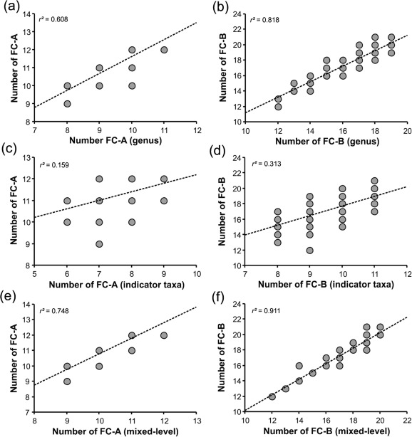

1. [Download : Download high-res image (363KB)](https://ars.els-cdn.com/content/image/1-s2.0-S1470160X20312474-gr5_lrg.jpg)
2. [Download : Download full-size image](https://ars.els-cdn.com/content/image/1-s2.0-S1470160X20312474-gr5.jpg)

Fig. 5. Relationship between the number of ant functional groups and the number of functional units for three levels of surrogates at the 65 study sites. (a) genus, (c) indicator taxa, and (e) mixed-level - all using a more general resolution (FC-A); (b) genus, (d) indicator taxa, and (f) mixed-level - all using a more specific resolution (FC-B).

### 3.3. Assessment of time and monetary costs

We found significant differences in the financial cost between the surrogates that we evaluated (*F*<sub>4,256</sub> = 4471, *P* < 0.001) (Fig. 6), with pairwise tests revealing significant differences between the surrogate resolutions (Tukey, *P* < 0.001). The surrogate that required the most effort was mixed-level, accounting for an average ~84% of the cost for species-level determinations. The genus and indicator taxa metrics required averages of ~42% and ~65% and of the total costs, respectively. As expected, identifying ants only down to the subfamily level is the cheapest, reducing total costs down to ~25% of that of species determination. Regarding the time to obtain the final product, the pattern was similar to the monetary cost, with relative values being mixed-level determination reduced to ~85%, followed by indicator taxa (~65%), genus (~43%) and subfamily (~20%) (Tables S5 and S6).

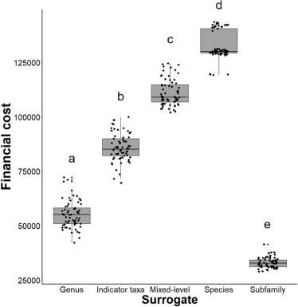

1. [Download : Download high-res image (98KB)](https://ars.els-cdn.com/content/image/1-s2.0-S1470160X20312474-gr6_lrg.jpg)
2. [Download : Download full-size image](https://ars.els-cdn.com/content/image/1-s2.0-S1470160X20312474-gr6.jpg)

Fig. 6. Relationship between the monetary costs and the different metrics used in the study. The different letters above the SD bars indicate that all means are significantly different (values are given in Table S6).

### 3.4. Synthesis of results

In summary, our results indicate that the mixed-level and indicator taxa presented the highest predictive values for both species richness and composition, and were considered to be excellent indicators. The genus predicted species composition at an acceptable level. Subfamily was not considered to be an acceptable indicator of species richness or composition and nor was genus for species richness. By contrast, mixed-level and genus surrogates were excellent indicators of FG composition and richness, although the less sensitive FC-A fared worse, but nevertheless acceptably; indicator taxa were acceptable indicators of FG composition but not of richness. The trends in monetary and time costs were essentially the opposite to the trends in indicator values (Table 1). If cost is not a factor, mixed-level surrogates perform the best overall, while indicator taxa perform second best for species richness/composition and genus performs best for FG. Surrogate relationships with the two sensitivity levels of FG did not differ appreciably, although FC-B tended to have a stronger correlation with surrogates than did FC-A (Table 1).

Table 1. Summary of degree of performance of the various surrogates, with 1 being the most desirable outcome and 4 the least.

[output not shown]

## 4. Discussion

The evaluation of species richness and composition patterns using surrogates has received increasing attention during terrestrial biodiversity investigations of various groups (e.g., Báldi, 2003 - Coleoptera, Diptera and Acari; Cardoso et al., 2004 - Araneae; Souza et al., 2016 - Formicidae). The use of a more accurate surrogates for invertebrate species represents a potentially significant advantage in the light of limited human and financial resources (Williams and Gaston, 1994, Oliver and Beattie, 1996a, Grimbacher et al., 2008), allowing non-specialists in the taxonomic groups concerned to incorporate these organisms in their own studies (Souza et al., 2016). However, together with the increase in the number of studies investigating the use of surrogates in recent decades (Andersen, 1995, Oliver and Beattie, 1996b, Pik et al., 1999, Vasconcelos et al., 2014, Souza et al., 2016, Souza et al., 2018, Gutiérrez et al., 2017), an increase in studies with varied and inconsistent results has also become evident (Lawler and White, 2008, Neeson et al., 2013, Oliveira and Tidon, 2013). According to Andersen (1995), such idiosyncrasies in the results may be due to variation in the number of species within the genera being considered. Other the factors that might influence the results include the: type of study area (Hess et al., 2006, Stork et al., 2014, Heino, 2014); sample scale (Sauberer et al., 2004); sampling effort (Vasconcelos et al., 2014); and taxonomic group concerned (Leal et al., 2010, Landeiro et al., 2012, Filgueiras et al., 2019, Vasconcelos et al., 2019). Nevertheless, a recent cumulative *meta*-analysis review of higher taxon surrogate approaches from 2007 to 2017 demonstrated consistent success in using higher taxa as surrogates over the period of the review (de Oliveira et al., 2020).

### 4.1. Taxonomic surrogates

As with some of the above-mentioned studies, our results do not always agree with previous investigations into ant surrogates. Earlier studies have sought to evaluate whether the genus level is a good surrogate for ant species (Andersen, 1995, Oliver and Beattie, 1996b). More recent studies that have demonstrated that genus is an effective surrogate for detecting patterns with species-level data include Pik et al., 1999, Heino and Soininen, 2007, Gallego et al., 2012, Souza et al., 2016, Souza et al., 2018, Gutiérrez et al., 2017. However, unlike in the current investigation, some of these studies did not compare the performance of genus against other possible surrogates. One exception is the study of Souza et al. (2016), which demonstrated that the genus level was the best substitute for ant richness. On the contrary our findings suggest that at although genus surrogates have some value, mainly due to the reduction of effort, expense and time, there is a more effective surrogates available, this being the mixed-level resolution.

Our results agree with Groc et al. (2010), whose study in French Guiana rainforest suggested that using mixed-level, and to a lesser extent indicator taxa surrogates result in a better prediction of species richness/composition than does genus. This outcome was different from what we originally hypothesized to be the best substitute for full species level determinations. We believe that the discrepancy between our and previous studies results from the different patterns of litter ants of the Atlantic rainforest when compared to ants from other strata or environments. Previous studies showed that Neotropical leaf-litter ant assemblages exhibit a relatively small number of species that are considered numerically dominant and a high number of habitat-specific species (Longino et al., 2002, Leponce et al., 2004, Groc et al., 2014). On the other hand, in the Amazon, although ant richness is locally high, beta diversity is low and species richness tends not to be influenced by the difference between habitats (Wilson, 1987, Majer and Delabie, 1994, Vasconcelos and Vilhena, 2006); this fact is mainly attributable to the large number of Amazonian ants that are habitat generalists (Wilson, 1987, Majer and Delabie, 1994). According to Oliveira and Tidon (2013), environmental conditions may also interfere in the development of surrogates for diversity. In addition, it is worth noting that even using similar scales and collection methods, studies conducted in different environments may not be comparable, since diversity may strongly vary for different reasons (Favreau et al., 2006).

### 4.2. Functional surrogates

Regarding functional diversity, our results suggest that the indicator taxa surrogate is a poor surrogate for FG richness but marginally better for FG composition. As we hypothesized, the mixed-level metric provides an excellent surrogate for both levels of FG sensitivity and of FC-B richness, and for FC-A the outcome was still good. Interestingly, genus level was considered an excellent surrogate for FG composition at both sensitivities and an acceptable surrogate of FG richness for FC-A and excellent one for FG-B. We believe the better performance of the genus surrogate for FG metrics than the taxonomic one is because species that are considered indicators do not exhibit great functional distinctions, that is, although they are representative of taxonomic diversity, they are not of functional diversity. This becomes evident when considering the relationship between the number of FGs in the original set of data and the indicator taxa species (Fig. 5C and D).

Studies have shown that taxonomic diversity can be a good surrogate for the functional diversity of ant assemblages (Bihn et al., 2010, Rocha-Ortega et al., 2018). This relationship is extremely important as its adoption would save time and resources needed to adequately quantify functional diversity (Rocha-Ortega et al., 2018). Although considerable variations in the number and composition of ant species between the study sites are observed (details in Koch et al., 2019), the composition of species and functional groups in the localities can generally be surprisingly stable, that is, the same genera and most functional groups are found in the different locations studied, this represents a considerable ecological redundancy and is evidenced mainly when we disregard rare species and consider FC-A. However, when we consider FC-B, which seeks to use more specific information about all species, we observe that although there is a substitution between species in the same genus, they can represent other functional groups, resulting in the composition of the genera being stable in different places, while the composition of functional groups is highly variable; a scenario of ecological complementarity.

Ants participate significantly in ecosystem structuring (Hölldobler and Wilson, 1990, Hoffmann and Andersen, 2003, Crist, 2009, Bihn et al., 2010), such as in seed dispersal (Christianini and Oliveira, 2009, Lengyel et al., 2009), in regulating the populations of several other groups (Izzo and Vasconcelos, 2005, Philpott and Armbrecht, 2006), and in promoting changes in the physical structure of the environment (Folgarait, 1998, Frouz and Jilková, 2008). Functional groups classify species on the basis of convergent morphological and life history characteristics (Brandão et al., 2012). Some authors consider this a simplified way of inferring about functional diversity, defending the use of functional traits. In fact, functional traits allow for quantification and greater prediction of functional diversity (Tilman et al., 1997; Cadotte et al., 2011). However, to obtain this information, a longer time and the specific level of identification is required. We believe that for ants the use of more specific information about the biology and natural history of genera in classifications of functional groups can allow to identify relationships with ecological, biogeographical, and evolutionary processes driving community structure.

### 4.3. Assessment of time and monetary costs

Different studies have shown that the Formicidae is a group of great utility and importance for environmental assessment and monitoring (Andersen and Majer, 2004, Underwood and Fisher, 2006, Delabie et al., 2009, Guzmán-Mendoza et al., 2016). Generally, the obtaining of these data requires more time than for vertebrates, thus increasing the total costs of projects (Pik et al., 1999, Moreno et al., 2008). The process of separation of individuals and species identification of Formicidae is far from trivial. In addition, the taxonomic knowledge of ecologists is rarely sufficient due to, among other factors, inexperience in taxonomy, difficulty in following the taxonomic changes (currently rather frequent in ant taxonomy), and the large quantity of collected material (Camarota and Pacheco, 2015). Our suggested surrogates aim to assist in overcoming these problems.

As demonstrated in other surrogate studies, genus level is the metric with the lowest costs (Souza et al., 2016, Souza et al., 2018), assuming that subfamily is removed as an option. However, in our study the most efficient surrogate resolution was the mixed-level one. Clearly we have a trade-off between reliability/efficiency and economy since the most effective surrogate considering the different metrics and evaluated performances – mixed-level – is also the one that requires the most time and monetary cost among the evaluated substitutes. The economy of time and resources generated by the use of an effective surrogate could allow a greater investment in other stages of the scientific study, such as the inclusion of more sampling sites or additional replicates in sampled areas, thus increasing study robustness, quality to the statistical arguments and better generalization of the results (Costa and Magnusson, 2010). The adoption of new approaches, such as surrogates, can save of time and money, and does not necessarily exempt the researcher from seeking the correct identification of the study group. The misidentification of a taxonomic unit can generate an error cascade, with implications not only in the understanding of biodiversity (Khuroo et al., 2007), but also in management and conservation outcomes (McNeely, 2002, Bortolus, 2008). As demonstrated in studies with different taxa, the use of biodiversity substitutes such as those proposed here may provide quality information on the biota's response to management interventions in order to conserve biodiversity (Lindenmayer et al., 2002, González et al., 2013, Barton et al., 2014, Westgate et al., 2014).

## 5. Conclusion

This is the first study that compares the use of surrogates for Formicidae from both the taxonomic and functional point of view. In conclusion, and differently from what was initially hypothesized, we have demonstrated that when considering both species richness and FGs, mixed-level would be the most suitable surrogate for Atlantic rainforest ants. However, we observe the trade-off between reliability/efficiency and economy, since the most effective surrogate was also the most expensive among those evaluated. However, this is still more economical in relation to time and monetary costs when compared to the species/morphospecies level. Comprehensive and robust ant studies generally result in hundreds of species to be separated from the rest of the invertebrate fauna, then assembled and identified (e.g., Souza et al., 2012, Vasconcelos et al., 2018, Santos et al., 2017, Koch et al., 2019). Our study lends support to this process by identifying suitable taxonomic and functional surrogates that allow the analysis of biological diversity from both the taxonomic and functional point of view.

## CRediT authorship contribution statement

**Elmo B.A. Koch:** Conceptualization, Methodology, Visualization, Writing - original draft. **Ivan Cardoso Nascimento:** Writing - review & editing. **Jonathan D. Majer:** Writing - review & editing. **Jacques H.C. Delabie:** Writing - review & editing, Project administration, Resources, Supervision.

## Declaration of Competing Interest

The authors declare that they have no known competing financial interests or personal relationships that could have appeared to influence the work reported in this paper.

## Acknowledgements

We thank all the anonymous reviewers who helped improve this manuscript. We wish to thank José R.M. dos Santos and José C.S. do Carmo (*in memoriam*), technicians from CEPLAC, who were responsible for field data collection. We are also grateful to the following funding agencies: Coordenação de Aperfeiçoamento de Pessoal de Nível Superior – Brazil (CAPES); and Fundação de Amparo à Pesquisa do Estado da Bahia (FAPESB). JHCD thanks the Conselho Nacional de Desenvolvimento Científico e Tecnológico (CNPq) for his research grant.

## Appendix A. Supplementary data

The following are the Supplementary data to this article:[Download : Download Acrobat PDF file (96KB)](https://ars.els-cdn.com/content/image/1-s2.0-S1470160X20312474-mmc1.pdf)

Supplementary data 1.

[Download : Download Acrobat PDF file (344KB)](https://ars.els-cdn.com/content/image/1-s2.0-S1470160X20312474-mmc2.pdf)

Supplementary data 2.

[Download : Download Acrobat PDF file (44KB)](https://ars.els-cdn.com/content/image/1-s2.0-S1470160X20312474-mmc3.pdf)

Supplementary data 3.

[Download : Download Acrobat PDF file (58KB)](https://ars.els-cdn.com/content/image/1-s2.0-S1470160X20312474-mmc4.pdf)

Supplementary data 4.

[Download : Download spreadsheet (33KB)](https://ars.els-cdn.com/content/image/1-s2.0-S1470160X20312474-mmc5.xlsx)

Supplementary data 5.

[Download : Download Acrobat PDF file (89KB)](https://ars.els-cdn.com/content/image/1-s2.0-S1470160X20312474-mmc6.pdf)

Supplementary data 6.

## References

**Agosti and Alonso, 2000**

Agosti, D., Alonso, L.E., 2000. The ALL Protocol: A Standard Protocol for the Collection of Ground-Dwelling Ants, in: Agosti, D.; Majer, J. M.; Alonso L. E. & Schultz T.R. (Eds.). Ants: Standard Methods for Measuring and Monitoring Biodiversity. pp. 204-206. Smithsonian Institution, Washington & London.

Google Scholar

**Agrawal et al., 2007**

A.A. Agrawal, D.D. Ackerly, F. Adler, *et al.***Filling key gaps in population and community ecology**

Front. Ecol. Environ., 5 (2007), pp. 145-152, 10.1890/1540-9295(2007)5[145:FKGIPA]2.0.CO;2

[View Record in Scopus](https://www.scopus.com/inward/record.url?eid=2-s2.0-34247173401&partnerID=10&rel=R3.0.0)[Google Scholar](https://scholar.google.com/scholar_lookup?title=Filling%20key%20gaps%20in%20population%20and%20community%20ecology&publication_year=2007&author=A.A.%20Agrawal&author=D.D.%20Ackerly&author=F.%20Adler)

**Andersen, 1995**

A.N. Andersen**Measuring more of biodiversity: Genus richness as a surrogate for species richness in Australian ant faunas**

Biol. Conserv., 73 (1) (1995), pp. 39-43, 10.1016/0006-3207(95)90059-4

[Article](https://www.sciencedirect.com/science/article/pii/0006320795900594)[Download PDF](https://www.sciencedirect.com/science/article/pii/0006320795900594/pdf?md5=9b780e29366c437971d8c08fec4b15ae&pid=1-s2.0-0006320795900594-main.pdf)[View Record in Scopus](https://www.scopus.com/inward/record.url?eid=2-s2.0-0028975389&partnerID=10&rel=R3.0.0)Google Scholar

**Andersen et al., 2002**

A.N. Andersen, B.D. Hoffmann, W.J. Muller, A.D. Griffiths**Using ants as bioindicators in land management: simplifying assessment of ant community responses**

J Appl Ecology, 39 (1) (2002), pp. 8-17, 10.1046/j.1365-2664.2002.00704.x

[View Record in Scopus](https://www.scopus.com/inward/record.url?eid=2-s2.0-0036193984&partnerID=10&rel=R3.0.0)Google Scholar

**Andersen and Majer, 2004**

Andersen, A.N., Majer, J.D., 2004. Ants show the way down under: invertebrates as bioindicators in land management. Front. Ecol. Environ. 2, 291–298. https://doi.org/10.1890/1540-9295(2004)002[0292:ASTWDU]2.0.CO;2.

Google Scholar

**Andersen, 2019**

Andersen, A.N., 2019. Responses of ant communities to disturbance: five principles for understanding the disturbance dynamics of a globally dominant faunal group. J. Anim. Ecol. 88, 350-362. https://doi.org/10.1111/1365-2656.12907.

Google Scholar

**Báldi, 2003**

A. Báldi**Using higher taxa as surrogates of species richness: a study based on 3700 Coleoptera, Diptera, and Acari species in Central-Hungarian reserves**

Basic Appl. Ecol., 4 (6) (2003), pp. 589-593, 10.1078/1439-1791-00193

[Article](https://www.sciencedirect.com/science/article/pii/S1439179104701528)[Download PDF](https://www.sciencedirect.com/science/article/pii/S1439179104701528/pdf?md5=54e7f3a2d0612bf813c23f83471ec24d&pid=1-s2.0-S1439179104701528-main.pdf)[CrossRef](https://doi.org/10.1078/1439-1791-00193)[View Record in Scopus](https://www.scopus.com/inward/record.url?eid=2-s2.0-0346269260&partnerID=10&rel=R3.0.0)Google Scholar

**Barton et al., 2014**

P.S. Barton, M.J. Westgate, W.P. Lane, C. MacGregor, D.B. Lindenmayer**Robustness of habitat-based surrogates of animal diversity: multitaxa comparison over time**

J. Appl. Ecol., 51 (2014), pp. 1434-1443, 10.1111/1365-2664.12290

[CrossRef](https://doi.org/10.1111/1365-2664.12290)[View Record in Scopus](https://www.scopus.com/inward/record.url?eid=2-s2.0-84925343035&partnerID=10&rel=R3.0.0)Google Scholar

**Basset et al., 2004**

Basset, Y., Novotny, V., Miller, S.E., Weiblen, G., Missa, O., Stewart, A.J.A., 2004. Conservation and biological monitoring of tropical forests: the role of parataxonomists. J. Appl. Ecol. 41, 163–174. https://doi.org/10.1111/j.1365-2664.2004.00878.x.

Google Scholar

**Beattie and Oliver, 1994**

A.J. Beattie, I. Oliver**Taxonomic minimalism**

Trends Ecol. Evol., 9 (1994), pp. 488-490

[Google Scholar](https://scholar.google.com/scholar_lookup?title=Taxonomic%20minimalism&publication_year=1994&author=A.J.%20Beattie&author=I.%20Oliver)

**Bestelmeyer et al., 2000**

Bestelmeyer, B.T., Agosti, D., Alonso, L.E., Brandão, C.R.F., Brown Jr, W.L., Delabie, J.H.C., Silvestre, R., 2000. Field techniques for the study of ground-living ants: an overview, description, and evaluation, in: Agosti, D., Majer, J.D., Alonso, L.E., Schultz, T.R. (Eds.). Ants: Standart Methods for Measuring and Monitoring Biodiversity. pp. 122–144. Smithsonian Institution, Washington, USA.

Google Scholar

**Bihn et al., 2010**

J.H. Bihn, G. Gebauer, R. Brandl**Loss of functional diversity of ant assemblages in secondary tropical forests**

Ecology, 91 (3) (2010), pp. 782-792, 10.1890/08-1276.1

[CrossRef](https://doi.org/10.1890/08-1276.1)[View Record in Scopus](https://www.scopus.com/inward/record.url?eid=2-s2.0-77950408822&partnerID=10&rel=R3.0.0)Google Scholar

**Bolton et al., 2007**

Bolton, B., Alpert, G., Ward, P.S., Naskrecki, P. 2007. Bolton’s catalogue of ants of the world: 1758–2005. Harvard University Press, Cambridge, MA.

Google Scholar

**Bortolus, 2008**

Bortolus, A., 2008. Error cascades in the biological sciences: the unwanted consequences of using bad taxonomy in ecology. AMBIO 37: 114–118. https://doi.org/10.1579/0044-7447(2008)37[114:ecitbs]2.0.co;2.

Google Scholar

**Brandão et al., 2012**

Brandão, C.R.F., Silva, R.R., Delabie, J.H.C., 2012. Neotropical ants (Hymenoptera) functional groups: Nutritional and applied implications, in: Panizzi, A.R., Parra, J.R.P., (Eds.). Insect Bioecology and Nutrition for Integrated Pest Management. pp. 213–236. Boca Raton: CRC Press.

Google Scholar

**Cadotte et al., 2011**

M.W. Cadotte, K. Cascadden, N. Mirotchnick**Beyond species: functional diversity and the maintenance of ecological process and services**

J. Appl. Ecol., 48 (2011), pp. 1079-1087, 10.1111/j.1365-2664.2011.02048.x

[CrossRef](https://doi.org/10.1111/j.1365-2664.2011.02048.x)[View Record in Scopus](https://www.scopus.com/inward/record.url?eid=2-s2.0-80052800716&partnerID=10&rel=R3.0.0)Google Scholar

**Camarota and Pacheco, 2015**

Camarota, F., Pacheco, R., 2015. A taxonomia no trabalho do ecólogo, in: Suguituru, S.S., Morini M.S.C., Feitosa, R.M., Silva, R.R., (Eds.). Formigas do Alto Tiête. pp. 73–80. Canal 6, Bauru, SP, Brasil.

Google Scholar

**Cardoso et al., 2004**

P. Cardoso, I. Silva, N.G. de Oliveira, A.R.M. Serrano**Higher taxa surrogates of spider (Araneae) diversity and their efficiency in conservation**

Biol. Conserv., 117 (4) (2004), pp. 453-459, 10.1016/j.biocon.2003.08.013

[Article](https://www.sciencedirect.com/science/article/pii/S0006320703003197)[Download PDF](https://www.sciencedirect.com/science/article/pii/S0006320703003197/pdfft?md5=b6c4d93846c64323b467fe1a3cc6879f&pid=1-s2.0-S0006320703003197-main.pdf)[View Record in Scopus](https://www.scopus.com/inward/record.url?eid=2-s2.0-1642390188&partnerID=10&rel=R3.0.0)[Google Scholar](https://scholar.google.com/scholar?q=Higher%20taxa%20surrogates%20of%20spider%20%20diversity%20and%20their%20efficiency%20in%20conservation)

**Chapin et al., 2000**

F.S. Chapin III, E.S. Zavaleta, V.T. Eviner, *et al.***Consequences of changing biotic diversity**

Nature, 405 (2000), pp. 234-242, 10.1038/35012241

[View Record in Scopus](https://www.scopus.com/inward/record.url?eid=2-s2.0-0034636490&partnerID=10&rel=R3.0.0)[Google Scholar](https://scholar.google.com/scholar_lookup?title=Consequences%20of%20changing%20biotic%20diversity&publication_year=2000&author=F.S.%20Chapin%20III&author=E.S.%20Zavaleta&author=V.T.%20Eviner)

**Costa and Magnusson, 2010**

F.R.C. Costa, W.E. Magnusson**The Need for Large-Scale, Integrated Studies of Biodiversity - the Experience of the Program for Biodiversity Research in Brazilian Amazonia**

Nat. Conserv., 08 (01) (2010), pp. 3-12, 10.4322/natcon.00801001

[CrossRef](https://doi.org/10.4322/natcon.00801001)[View Record in Scopus](https://www.scopus.com/inward/record.url?eid=2-s2.0-79951708440&partnerID=10&rel=R3.0.0)Google Scholar

**Crist, 2009**

T.O. Crist**Biodiversity, species interactions, and functional roles of ants (Hymenoptera: Formicidae) in fragmented landscapes: a review**

Myrmecol. News, 12 (2009), pp. 3-13

[View Record in Scopus](https://www.scopus.com/inward/record.url?eid=2-s2.0-62349089540&partnerID=10&rel=R3.0.0)[Google Scholar](https://scholar.google.com/scholar?q=Biodiversity,%20species%20interactions,%20and%20functional%20roles%20of%20ants%20%20in%20fragmented%20landscapes:%20a%20review)

**Christianini and Oliveira, 2009**

A.V. Christianini, P.S. Oliveira**The relevance of ants as seed rescuers of a primarily bird-dispersed tree in the Neotropical cerrado savanna**

Oecologia, 160 (4) (2009), pp. 735-745, 10.1007/s00442-009-1349-2

[CrossRef](https://doi.org/10.1007/s00442-009-1349-2)[View Record in Scopus](https://www.scopus.com/inward/record.url?eid=2-s2.0-67649216611&partnerID=10&rel=R3.0.0)Google Scholar

**Dalerum et al., 2012**

F. Dalerum, E.Z. Cameron, K. Kunkel, M.J. Somers**Interactive effects of species richness and species traits on functional diversity and redundancy**

Theor. Ecol., 5 (1) (2012), pp. 129-139, 10.1007/s12080-010-0104-y

[CrossRef](https://doi.org/10.1007/s12080-010-0104-y)[View Record in Scopus](https://www.scopus.com/inward/record.url?eid=2-s2.0-84855893463&partnerID=10&rel=R3.0.0)Google Scholar

**De Bello et al., 2010**

F. De Bello, S. Lavorel, S. Díaz, *et al.***Towards assessment of multiple ecosystem processes and services via functional traits**

Biodiver. Conserv., 19 (2010), pp. 2873-2893, 10.1007/s10531-010-9850-9

[CrossRef](https://doi.org/10.1007/s10531-010-9850-9)[View Record in Scopus](https://www.scopus.com/inward/record.url?eid=2-s2.0-77955556848&partnerID=10&rel=R3.0.0)Google Scholar

**Delabie et al., 2000**

Delabie, J.H.C., Agosti, D., Nascimento, I.C., 2000. Litter ant communities of the Brazilian Atlantic rain forest region, in: Agosti, D., Majer, J.D., Alonso, L.E., Schultz, T.R. (eds). Sampling Ground-dwelling Ants: Case Studies from the World’s Rainforests. pp. 1–17. Curtin University School of Environmental Biology Bulletin No. 18, Perth, Australia.

Google Scholar

**Delabie et al., 2009**

J.H.C. Delabie, R. Céréghino, S. Groc, A. Dejean, M. Gibernau, B. Corbara, A. Dejean**Ants as biological indicators of Wayana Amerindian land use in French Guiana**

C.R. Biol., 332 (7) (2009), pp. 673-684, 10.1016/j.crvi.2009.01.006

[Article](https://www.sciencedirect.com/science/article/pii/S1631069109000286)[Download PDF](https://www.sciencedirect.com/science/article/pii/S1631069109000286/pdfft?md5=cc0cd6935346b852a19a7b9877b41ff5&pid=1-s2.0-S1631069109000286-main.pdf)[View Record in Scopus](https://www.scopus.com/inward/record.url?eid=2-s2.0-67349177756&partnerID=10&rel=R3.0.0)Google Scholar

**Delabie et al., 2021**

Delabie, J.H.C., Koch, E., Dodonov, P., Caitano, B., DaRocha, W., Jahyny, B., Leponce, M., Majer, J., Mariano, C.S.F., 2021. Sampling and analysis methods for ant diversity assessment. in: Santos, J.C., Fernandes, G.W. (eds.) Measuring Arthropod Biodiversity - A Handbook of Sampling Methods. pp. 13–54. Springer, Cham. https://doi.org/10.1007%2F978-3-030-53226-0_2.

Google Scholar

**Díaz et al., 2013**

S. Díaz, A. Purvis, J.H.C. Cornelissen, G.M. Mace, M.J. Donoghue, R.M. Ewers, P. Jordano, W.D. Pearse**Functional traits, the phylogeny of function, and ecosystem service vulnerability**

Ecol. Evol., 3 (9) (2013), pp. 2958-2975, 10.1002/ece3.601

[CrossRef](https://doi.org/10.1002/ece3.601)[View Record in Scopus](https://www.scopus.com/inward/record.url?eid=2-s2.0-84887009273&partnerID=10&rel=R3.0.0)Google Scholar

**Douglas and Matthews, 1992**

M.E. Douglas, W.J. Matthews**Does Morphology Predict Ecology? Hypothesis Testing within a Freshwater Stream Fish Assemblage**

Oikos, 65 (2) (1992), p. 213, 10.2307/3545012

[CrossRef](https://doi.org/10.2307/3545012)[View Record in Scopus](https://www.scopus.com/inward/record.url?eid=2-s2.0-84970295361&partnerID=10&rel=R3.0.0)[Google Scholar](https://scholar.google.com/scholar?q=Does%20Morphology%20Predict%20Ecology%20Hypothesis%20Testing%20within%20a%20Freshwater%20Stream%20Fish%20Assemblage)

**Ellis, 1985**

D. Ellis**Taxonomic sufficiency in pollution assessment**

Mar. Pollut. Bull., 16 (12) (1985), p. 459, 10.1016/0025-326X(85)90362-5

[Article](https://www.sciencedirect.com/science/article/pii/0025326X85903625)[Download PDF](https://www.sciencedirect.com/science/article/pii/0025326X85903625/pdfft?md5=c70367c07ebe2d9bb0938cb5a0c12094&pid=1-s2.0-0025326X85903625-main.pdf)[View Record in Scopus](https://www.scopus.com/inward/record.url?eid=2-s2.0-2542469304&partnerID=10&rel=R3.0.0)[Google Scholar](https://scholar.google.com/scholar_lookup?title=Taxonomic%20sufficiency%20in%20pollution%20assessment&publication_year=1985&author=D.%20Ellis)

**Favreau et al., 2006**

J.M. Favreau, C.A. Drew, G.R. Hess, M.J. Rubino, F.H. Koch, K.A. Eschelbach**Recommendations for Assessing the Effectiveness of Surrogate Species Approaches**

Biodivers. Conserv., 15 (12) (2006), pp. 3949-3969, 10.1007/s10531-005-2631-1

[CrossRef](https://doi.org/10.1007/s10531-005-2631-1)[View Record in Scopus](https://www.scopus.com/inward/record.url?eid=2-s2.0-33845408286&partnerID=10&rel=R3.0.0)Google Scholar

**Filgueiras et al., 2019**

B.K.C. Filgueiras, D.H.A. Melo, A.N. Andersen, M. Tabarelli, I.R. Leal**Cross-taxon congruence in insect responses to fragmentation of Brazilian Atlantic forest**

Ecol. Ind., 98 (2019), pp. 523-530, 10.1016/j.ecolind.2018.11.036

[Article](https://www.sciencedirect.com/science/article/pii/S1470160X18308999)[Download PDF](https://www.sciencedirect.com/science/article/pii/S1470160X18308999/pdfft?md5=1d083233f865f324e53c07b2726d88c6&pid=1-s2.0-S1470160X18308999-main.pdf)[View Record in Scopus](https://www.scopus.com/inward/record.url?eid=2-s2.0-85056782203&partnerID=10&rel=R3.0.0)Google Scholar

**Folgarait, 1998**

P.J. Folgarait**Ant biodiversity and its relationship to ecosystem functioning: a review**

Biodivers. Conserv., 7 (9) (1998), pp. 1221-1244, 10.1023/A:1008891901953

[View Record in Scopus](https://www.scopus.com/inward/record.url?eid=2-s2.0-0032435107&partnerID=10&rel=R3.0.0)[Google Scholar](https://scholar.google.com/scholar_lookup?title=Ant%20biodiversity%20and%20its%20relationship%20to%20ecosystem%20functioning%3A%20a%20review&publication_year=1998&author=P.J.%20Folgarait)

**Frouz and Jilková, 2008**

J. Frouz, V. Jilková**The effect of ants on soil properties and process (Hymenoptera: Formicidae)**

Mirmecol. News, 11 (2008), pp. 191-199

[View Record in Scopus](https://www.scopus.com/inward/record.url?eid=2-s2.0-77950594275&partnerID=10&rel=R3.0.0)[Google Scholar](https://scholar.google.com/scholar?q=The%20effect%20of%20ants%20on%20soil%20properties%20and%20process)

**Gallego et al., 2012**

I. Gallego, T.A. Davidson, E. Jeppesen, C. Pérez-Martínez, P. Sánchez-Castillo, M. Juan, F. Fuentes-Rodríguez, D. León, P. Peñalver, J. Toja, J.J. Casas**Taxonomic or ecological approaches? Searching for phytoplankton surrogates in the determination of richness and assemblage composition in ponds**

Ecol. Ind., 18 (2012), pp. 575-585, 10.1016/j.ecolind.2012.01.002

[Article](https://www.sciencedirect.com/science/article/pii/S1470160X12000179)[Download PDF](https://www.sciencedirect.com/science/article/pii/S1470160X12000179/pdfft?md5=f7a9e3c36ee3c3acf27eab9b4913e850&pid=1-s2.0-S1470160X12000179-main.pdf)[View Record in Scopus](https://www.scopus.com/inward/record.url?eid=2-s2.0-84856982209&partnerID=10&rel=R3.0.0)Google Scholar

**Gardner et al., 2008**

Gardner, T.A., Barlow, J., Araujo, I.S, et al., 2008. The cost- effectiveness of biodiversity surveys in tropical forests. Ecol. Lett. 11, 139–150. https://doi.org/10.1111/j.1461-0248.2007.01133.x.

Google Scholar

**Gaston, 1996**

K.J. Gaston**Biodiversity - congruence**

Prog. Phys. Geogr.: Earth Environ., 20 (1) (1996), pp. 105-112, 10.1177/030913339602000108

[CrossRef](https://doi.org/10.1177/030913339602000108)[View Record in Scopus](https://www.scopus.com/inward/record.url?eid=2-s2.0-0000545102&partnerID=10&rel=R3.0.0)[Google Scholar](https://scholar.google.com/scholar_lookup?title=Biodiversity%20-%20congruence&publication_year=1996&author=K.J.%20Gaston)

**Gerisch et al., 2012**

M. Gerisch, V. Agostinelli, K. Henle, F. Dziock**More species, but all do the same: contrasting effects of flood disturbance on ground beetle functional and species diversity**

Oikos, 121 (4) (2012), pp. 508-515, 10.1111/j.1600-0706.2011.19749.x

[CrossRef](https://doi.org/10.1111/j.1600-0706.2011.19749.x)[View Record in Scopus](https://www.scopus.com/inward/record.url?eid=2-s2.0-84858333285&partnerID=10&rel=R3.0.0)Google Scholar

**Grimbacher et al., 2008**

Grimbacher, P.S., Catterall, C.P. & Kitching, R.L., 2008. Detecting the effects of environmental change above the species level with beetles in a fragmented tropical rainforest landscape. Ecol. Entomol. 33, 66–79. https://doi.org/10.1111/j.1365-2311.2007.00937.x.

Google Scholar

**Groc et al., 2010**

S. Groc, J.H.C. Delabie, J.T. Longino, J. Orivel, J.D. Majer, H.L. Vasconcelos, A. Dejean**A new method based on taxonomic sufficiency to simplify studies on Neotropical ant assemblages**

Biol. Conserv., 143 (11) (2010), pp. 2832-2839, 10.1016/j.biocon.2010.07.034

[Article](https://www.sciencedirect.com/science/article/pii/S000632071000340X)[Download PDF](https://www.sciencedirect.com/science/article/pii/S000632071000340X/pdfft?md5=877bcceed23fdbd791ded02b2edaa1dd&pid=1-s2.0-S000632071000340X-main.pdf)[View Record in Scopus](https://www.scopus.com/inward/record.url?eid=2-s2.0-77956884862&partnerID=10&rel=R3.0.0)Google Scholar

**Groc et al., 2014**

S. Groc, J.H.C. Delabie, F. Fernández, M. Leponce, J. Orivel, R. Silvestre, H.L. Vasconcelos, A. Dejean**Leaf–litter ant communities (Hymenoptera: Formicidae) in a pristine Guianese rainfores: stable functional structure versus high species turnover**

Myrmecol. News, 19 (2014), pp. 43-51

[View Record in Scopus](https://www.scopus.com/inward/record.url?eid=2-s2.0-84894500729&partnerID=10&rel=R3.0.0)[Google Scholar](https://scholar.google.com/scholar?q=Leaflitter%20ant%20communities%20%20in%20a%20pristine%20Guianese%20rainfores:%20stable%20functional%20structure%20versus%20high%20species%20turnover)

**González et al., 2013**

E. González, L. Rochefort, S. Boudreau, S. Hugron, M. Poulin**Can indicator species predict restoration outcomes early in the monitoring process? a case study with peatlands**

Ecol. Ind., 32 (2013), pp. 232-238, 10.1016/j.ecolind.2013.03.019

[Article](https://www.sciencedirect.com/science/article/pii/S1470160X13001258)[Download PDF](https://www.sciencedirect.com/science/article/pii/S1470160X13001258/pdfft?md5=591ce7d14b5b76f748f313a1e41ea0ca&pid=1-s2.0-S1470160X13001258-main.pdf)[View Record in Scopus](https://www.scopus.com/inward/record.url?eid=2-s2.0-84876702745&partnerID=10&rel=R3.0.0)[Google Scholar](https://scholar.google.com/scholar?q=Can%20indicator%20species%20predict%20restoration%20outcomes%20early%20in%20the%20monitoring%20process%20a%20case%20study%20with%20peatlands)

**Gutiérrez et al., 2017**

Gutiérrez, J.A.M., Roussea, G.X., Andrade-Silva J, Delabie, J.H.C., 2017. Taxones superiores de hormigas como sustitutos de la riqueza de especies, en una cronosecuencia de bosques secundarios, bosque primario y sistemas agroforestales en la Amazonía Oriental, Brasil. Rev. Biol. Trop. 65, 279–291. http://dx.doi.org/10.15517/rbt.v65i1.23526.

Google Scholar

**Guzmán-Mendoza et al., 2016**

Guzmán-Mendoza, R., Castaño-Meneses, G., Nuñez- Palenius, H., 2016. The diversity of ant communities (Hymenoptera: Formicidae) and their connections with other arthropods from three temperate forests of Central Mexico. Rev. Biol. Trop. 64, 571– https://doi.org/585. 10.15517/rbt.v64i2.18979.

Google Scholar

**Haines-Young, 2013**

Haines-Young, P.M., 2013. Common International Classification of Ecosystem Services (CICES): Consultation on Version 4, August-December 2012. EEA Framework Contract No EEA/IEA/09/003.

Google Scholar

**Hawkins, 2001**

B.A. Hawkins**Ecology's oldest pattern?**

Trends Ecol. Evol., 16 (8) (2001), p. 470, 10.1016/S0169-5347(01)02197-8

[Article](https://www.sciencedirect.com/science/article/pii/S0169534701021978)[Download PDF](https://www.sciencedirect.com/science/article/pii/S0169534701021978/pdfft?md5=7fb32b5f4e145406e7d997181d5c9069&pid=1-s2.0-S0169534701021978-main.pdf)[Google Scholar](https://scholar.google.com/scholar?q=Ecologys%20oldest%20pattern)

**Heino and Soininen, 2007**

J. Heino, J. Soininen**Are higher taxa adequate surrogates for species-level assemblage patterns and species richness in stream organisms?**

Biol. Conserv., 137 (2007), pp. 78-89, 10.1016/S0169-5347(01)02197-8

[Article](https://www.sciencedirect.com/science/article/pii/S0006320707000493)[Download PDF](https://www.sciencedirect.com/science/article/pii/S0006320707000493/pdfft?md5=7058a881baf7856467e59d26a8e135ff&pid=1-s2.0-S0006320707000493-main.pdf)[View Record in Scopus](https://www.scopus.com/inward/record.url?eid=2-s2.0-34047167943&partnerID=10&rel=R3.0.0)[Google Scholar](https://scholar.google.com/scholar?q=Are%20higher%20taxa%20adequate%20surrogates%20for%20species-level%20assemblage%20patterns%20and%20species%20richness%20in%20stream%20organisms)

**Heino, 2014**

J. Heino**Taxonomic surrogacy, numerical resolution and responses of stream macroinvertebrate communities to ecological gradients: Are the inferences transferable among regions?**

Ecol. Ind., 36 (2014), pp. 186-194, 10.1016/j.ecolind.2013.07.022

[Article](https://www.sciencedirect.com/science/article/pii/S1470160X13002847)[Download PDF](https://www.sciencedirect.com/science/article/pii/S1470160X13002847/pdfft?md5=61e8e24262b4c6a2a649b4db3f093a80&pid=1-s2.0-S1470160X13002847-main.pdf)[View Record in Scopus](https://www.scopus.com/inward/record.url?eid=2-s2.0-84882750060&partnerID=10&rel=R3.0.0)Google Scholar

**Hess et al., 2006**

G.R. Hess, R.A. Bartel, A.K. Leidner, K.M. Rosenfeld, M.J. Rubino, S.B. Snider, T.H. Ricketts**Effectiveness of biodiversity indicators varies with extent, grain, and region**

Biol. Conserv., 132 (4) (2006), pp. 448-457, 10.1016/j.biocon.2006.04.037

[Article](https://www.sciencedirect.com/science/article/pii/S0006320706001960)[Download PDF](https://www.sciencedirect.com/science/article/pii/S0006320706001960/pdfft?md5=0fe4dd57f3cfced9e0282fed2e914696&pid=1-s2.0-S0006320706001960-main.pdf)[View Record in Scopus](https://www.scopus.com/inward/record.url?eid=2-s2.0-33748470119&partnerID=10&rel=R3.0.0)Google Scholar

**Hoffmann and Andersen, 2003**

Hoffmann, B.D., Andersen, A.N., 2003. Responses of ants to disturbance in Australia, with particular reference to functional groups. Austral Ecol. 28, 444–464. https://doi.org/10.1046/j.1442-9993.2003.01301.x.

Google Scholar

**Hooper et al., 2005**

D.U. Hooper, F.S. Chapin III, J.J. Ewel, A. Hector, P. Inchausti, S. Lavorel, J.H. Lawton, D.M. Lodge, M. Loreau, S. Naeem, B. Schmid, H. Setälä, A.J. Symstad, J. Vandermeer, D.A. Wardle**Effects of biodiversity on ecosystem functioning: a consensus of current knowledge**

Ecol. Monogr., 75 (1) (2005), pp. 3-35, 10.1890/04-0922

[CrossRef](https://doi.org/10.1890/04-0922)[View Record in Scopus](https://www.scopus.com/inward/record.url?eid=2-s2.0-20044377582&partnerID=10&rel=R3.0.0)Google Scholar

**Hölldobler and Wilson, 1990**

Hölldobler, B., Wilson, E. 1990. The Ants. Harvard University Press, Cambridge, Massachusetss, USA.

[Google Scholar](https://scholar.google.com/scholar?q=H%C3%B6lldobler,%20B.,%20Wilson,%20E.%201990.%20The%20Ants.%20Harvard%20University%20Press,%20Cambridge,%20Massachusetss,%20USA.)

**Izzo and Vasconcelos, 2005**

T.J. Izzo, H.L. Vasconcelos**Ants and plant size shape the structure of the arthropod community of *Hirtella myrmecophila*, an Amazonian ant-plant**

Ecol. Entomol., 30 (6) (2005), pp. 650-656, 10.1111/j.0307-6946.2005.00736.x

[CrossRef](https://doi.org/10.1111/j.0307-6946.2005.00736.x)[View Record in Scopus](https://www.scopus.com/inward/record.url?eid=2-s2.0-33748882448&partnerID=10&rel=R3.0.0)Google Scholar

**Kallimanis et al., 2012**

A.S. Kallimanis, A.D. Mazaris, D. Tsakanikas, P. Dimopoulos, J.D. Pantis, S.P. Sgardelis**Efficient biodiversity monitoring: Which taxonomic level to study?**

Ecol. Ind., 15 (1) (2012), pp. 100-104, 10.1016/j.ecolind.2011.09.024

[Article](https://www.sciencedirect.com/science/article/pii/S1470160X11003116)[Download PDF](https://www.sciencedirect.com/science/article/pii/S1470160X11003116/pdfft?md5=1a5a51dd4e4ddf14643eb79747805bee&pid=1-s2.0-S1470160X11003116-main.pdf)[View Record in Scopus](https://www.scopus.com/inward/record.url?eid=2-s2.0-81755184748&partnerID=10&rel=R3.0.0)[Google Scholar](https://scholar.google.com/scholar?q=Efficient%20biodiversity%20monitoring:%20Which%20taxonomic%20level%20to%20study)

**Kaspari and Majer, 2000**

Kaspari, M., Majer, J.D., 2000. Using ants to monitor environmental change, in: Agosti, D., Majer, J.D., Alonso, L.E., Schultz, T.R. (Eds.), Ants: Standard Methods for Measuring and Monitoring Biodiversity. Smithsonian Institution Press, Washington, DC, pp. 89–98.

Google Scholar

**Kessler et al., 2011**

Kessler, M., Abrahamczyk, S., Bos, M., et al. 2011. Cost-effectiveness of plant and animal biodiversity indicators in tropical forest and agroforest habitats. J. Appl. Ecol. 48, 330–339. https://doi.org/10.1111/j.1365-2664.2010.01932.x.

Google Scholar

**Khuroo et al., 2007**

A.A. Khuroo, G.H. Dar, Z.S. Khan, A.H. Malik**Exploring an inherent interface between taxonomy and biodiversity: Current problems and future challenges**

J. Nat. Conser., 15 (4) (2007), pp. 256-261, 10.1016/j.jnc.2007.07.003

[Article](https://www.sciencedirect.com/science/article/pii/S1617138107000222)[Download PDF](https://www.sciencedirect.com/science/article/pii/S1617138107000222/pdfft?md5=dd774098d781e8c398c42ef783220bcb&pid=1-s2.0-S1617138107000222-main.pdf)[View Record in Scopus](https://www.scopus.com/inward/record.url?eid=2-s2.0-36048970464&partnerID=10&rel=R3.0.0)Google Scholar

**Koch et al., 2019**

Koch, E.B.A, Santos, J.R.M., Nascimento, I.C., Delabie, J.H.C. 2019. Comparative evaluation of taxonomic and functional diversities of leaf-litter ants of the Brazilian Atlantic Forest. Turk. J. Zool. 43, 437–456. https://doi.org/10.3906/zoo-1811-7.

Google Scholar

**Landeiro et al., 2012**

V.L. Landeiro, L.M. Bini, F.R.C. Costa, E. Franklin, A. Nogueira, J.L.P. de Souza, J. Moraes, W.E. Magnusson**How far can we go in simplifying biomonitoring assessments? An integrated analysis of taxonomic surrogacy, taxonomic sufficiency and numerical resolution in a megadiverse region**

Ecol. Ind., 23 (2012), pp. 366-373, 10.1016/j.ecolind.2012.04.023

[Article](https://www.sciencedirect.com/science/article/pii/S1470160X12001859)[Download PDF](https://www.sciencedirect.com/science/article/pii/S1470160X12001859/pdfft?md5=10e1afed45164ce1abd4e5e2e801f686&pid=1-s2.0-S1470160X12001859-main.pdf)[View Record in Scopus](https://www.scopus.com/inward/record.url?eid=2-s2.0-84861003905&partnerID=10&rel=R3.0.0)Google Scholar

**Lavorel and Garnier, 2002**

Lavorel, S., Garnier, E. 2002. Predicting changes in community composition and ecosystem functioning from plant traits: revisiting the Holy Grail. Funct. Ecol. 16, 545–556. https://doi.org/10.1046/j.1365-2435.2002.00664.x.

Google Scholar

**Lawler and White, 2008**

Lawler, J.J., White, D., 2008. Assessing the mechanisms behind successful surrogates for biodiversity in conservation planning. Anim. Conserv. 11, 270–280. https://doi.org/10.1111/j.1469-1795.2008.00176.x.

Google Scholar

**Lawton et al., 1998**

J.H. Lawton, D.E. Bignell, B. Bolton, G.F. Bloemers, P. Eggleton, P.M. Hammond, M. Hodda, R.D. Holt, T.B. Larsen, N.A. Mawdsley, N.E. Stork, D.S. Srivastava, A.D. Watt**Biodiversity inventories, indicator taxa and effects of habitat modification in tropical forest**

Nature, 391 (6662) (1998), pp. 72-76, 10.1038/34166

[View Record in Scopus](https://www.scopus.com/inward/record.url?eid=2-s2.0-0031890663&partnerID=10&rel=R3.0.0)Google Scholar

**Leal et al., 2010**

I.R. Leal, A.G.D. Bieber, M. Tabarelli, A.N. Andersen**Biodiversity surrogacy: indicator taxa as predictors of total species richness in Brazilian Atlantic forest and Caatinga**

Biodivers Conserv, 19 (12) (2010), pp. 3347-3360, 10.1007/s10531-010-9896-8

[CrossRef](https://doi.org/10.1007/s10531-010-9896-8)[View Record in Scopus](https://www.scopus.com/inward/record.url?eid=2-s2.0-77958002961&partnerID=10&rel=R3.0.0)Google Scholar

**Lengyel et al., 2009**

Lengyel, S., A.D. Gove, A.M. Latimer, J.D. Majer, Dunn, R.R. 2009. Ants sow the seeds of global diversification in flowering plants. PloS One. 4, e5480. https://doi.org/10.1371/journal.pone.0005480.

Google Scholar

**Leponce et al., 2004**

Leponce, M., Theunis, L., Delabie, J. H. C., & Roisin, Y., 2004. Scale dependence of diversity measures in a leaf-litter ant assemblage. Ecography 27, 253–267. https://doi.org/10.1111/j.0906-7590.2004.03715.x.

Google Scholar

**Lindenmayer et al., 2002**

D.B. Lindenmayer, A.D. Manning, P.L. Smith, H.P. Possingham, J. Fischer, I. Oliver, M.A. McCarthy**The Focal‐Species Approach and Landscape Restoration: a Critique**

Conserv. Biol., 16 (2) (2002), pp. 338-345, 10.1046/j.1523-1739.2002.00450.x

[View Record in Scopus](https://www.scopus.com/inward/record.url?eid=2-s2.0-0036230724&partnerID=10&rel=R3.0.0)[Google Scholar](https://scholar.google.com/scholar?q=The%20FocalSpecies%20Approach%20and%20Landscape%20Restoration:%20a%20Critique)

**Lindenmayer and Likens, 2011**

D.B. Lindenmayer, G.E. Likens**Direct Measurement Versus Surrogate Indicator Species for Evaluating Environmental Change and Biodiversity Loss**

Ecosystems, 14 (1) (2011), pp. 47-59, 10.1007/s10021-010-9394-6

[CrossRef](https://doi.org/10.1007/s10021-010-9394-6)[View Record in Scopus](https://www.scopus.com/inward/record.url?eid=2-s2.0-79551637564&partnerID=10&rel=R3.0.0)Google Scholar

**Longino et al., 2002**

J.T. Longino, J. Coddington, R.K. Colwell**The ant fauna of a tropical rain forest: estimating species richness three different ways**

Ecology, 83 (2002), pp. 689-702, 10.1890/0012-9658(2002)083[0689:TAFOAT]2.0.CO;2

[View Record in Scopus](https://www.scopus.com/inward/record.url?eid=2-s2.0-0003184420&partnerID=10&rel=R3.0.0)Google Scholar

**Majer and Delabie, 1994**

J.D. Majer, J.H.C. Delabie**Comparison of the ant communities of annually inundated and terra firme forests at Trombetas in the Brazilian Amazon**

Ins. Soc, 41 (4) (1994), pp. 343-359, 10.1007/BF01240639

[View Record in Scopus](https://www.scopus.com/inward/record.url?eid=2-s2.0-0028189115&partnerID=10&rel=R3.0.0)Google Scholar

**Majer et al., 2007**

J.D. Majer, G. Orabi, L. Bisevac**Ants (Hymenoptera: Formicidae) pass the bioindicator scorecard**

Myrmecol. News, 10 (2007), pp. 69-76

[View Record in Scopus](https://www.scopus.com/inward/record.url?eid=2-s2.0-62349118658&partnerID=10&rel=R3.0.0)[Google Scholar](https://scholar.google.com/scholar?q=Ants%20%20pass%20the%20bioindicator%20scorecard)

**Mandelik et al., 2010**

Y. Mandelik, U. Roll, A. Fleischer**Cost-efciency of biodiversity indicators for Mediterranean ecosystems and the efects of socio-economic factors**

J. Appl. Ecol., 47 (2010), pp. 1179-1188, 10.1111/j.1365-2664.2010.01864.x

[CrossRef](https://doi.org/10.1111/j.1365-2664.2010.01864.x)[View Record in Scopus](https://www.scopus.com/inward/record.url?eid=2-s2.0-78149350219&partnerID=10&rel=R3.0.0)Google Scholar

**Mantel, 1967**

N. Mantel**The detection of disease clustering and a generalized regression approach**

Cancer Res., 27 (1967), pp. 209-220, 10.1111/j.1365-2745.2008.01450.x

[View Record in Scopus](https://www.scopus.com/inward/record.url?eid=2-s2.0-0014054519&partnerID=10&rel=R3.0.0)[Google Scholar](https://scholar.google.com/scholar_lookup?title=The%20detection%20of%20disease%20clustering%20and%20a%20generalized%20regression%20approach&publication_year=1967&author=N.%20Mantel)

**Manthey and Fridley, 2009**

Manthey, M., Fridley, J. D., 2009. Beta diversity metrics and the estimation of niche width via species co-occurrence data: reply to Zeleny. J. Ecol. 97, 18–22. https://doi.org/10.1111/j.1365-2745.2008.01450.x.

Google Scholar

**McGeogh, 1998**

McGeoch, M.A., 1998. The selection, testing and application of terrestrial insects as bioindicators. Biol. Rev. 73, 181–201. https://doi.org/10.1111/j.1469-185X.1997.tb00029.x.

Google Scholar

**McGeoch, 2007**

McGeoch, M.A. 2007. Insects and bioindication: theory and progress. in: Stewart, A.J.A., New, T.R., Lewis, O.T., (Eds.). Insect conservation biology. pp. 144–174. Wallingford, CABI.

Google Scholar

**McNeely, 2002**

J.A. McNeely**The role of taxonomy in conserving biodiversity**

J. Nat. Conser., 10 (3) (2002), pp. 145-153, 10.1078/1617-1381-00015

[Article](https://www.sciencedirect.com/science/article/pii/S1617138104700151)[Download PDF](https://www.sciencedirect.com/science/article/pii/S1617138104700151/pdfft?md5=ad89f6675bca99077f6cd3b2f59a892e&pid=1-s2.0-S1617138104700151-main.pdf)[CrossRef](https://doi.org/10.1078/1617-1381-00015)[View Record in Scopus](https://www.scopus.com/inward/record.url?eid=2-s2.0-0036445206&partnerID=10&rel=R3.0.0)[Google Scholar](https://scholar.google.com/scholar_lookup?title=The%20role%20of%20taxonomy%20in%20conserving%20biodiversity&publication_year=2002&author=J.A.%20McNeely)

**Mittermeier et al., 1998**

R.A. Mittermeier, N. Myers, J.B. Thomsen, G.A.B. da Fonseca, S. Olivieri**Biodiversity Hotspots and Major Tropical Wilderness Areas: Approaches to Setting Conservation Priorities**

Conserv. Biol., 12 (3) (1998), pp. 516-520, 10.1046/j.1523-1739.1998.012003516.x

[View Record in Scopus](https://www.scopus.com/inward/record.url?eid=2-s2.0-0031861298&partnerID=10&rel=R3.0.0)Google Scholar

**Moore et al., 2009**

S.A. Moore, T.J. Wallington, R.J. Hobbs, P.R. Ehrlich, C.S. Holling, S. Levin, D. Lindenmayer, C. Pahl-Wostl, H. Possingham, M.G. Turner, M. Westoby**Diversity in Current Ecological Thinking: Implications for Environmental Management**

Environ. Manage., 43 (1) (2009), pp. 17-27, 10.1007/s00267-008-9187-2

[CrossRef](https://doi.org/10.1007/s00267-008-9187-2)[View Record in Scopus](https://www.scopus.com/inward/record.url?eid=2-s2.0-57749191053&partnerID=10&rel=R3.0.0)Google Scholar

**Moreno et al., 2008**

C.E. Moreno, R. Guevara, G. Sánchez-Rojas, D. Téllez, J.R. Verdú**Community level patterns in diverse systems: A case study of litter fauna in a Mexican pine-oak forest using higher taxa surrogates and re-sampling methods**

Acta Oecologica, 33 (1) (2008), pp. 73-84, 10.1016/j.actao.2007.09.002

[Article](https://www.sciencedirect.com/science/article/pii/S1146609X07001099)[Download PDF](https://www.sciencedirect.com/science/article/pii/S1146609X07001099/pdfft?md5=604d1cd3adcf19aeec9921df158b22e5&pid=1-s2.0-S1146609X07001099-main.pdf)[View Record in Scopus](https://www.scopus.com/inward/record.url?eid=2-s2.0-38649104459&partnerID=10&rel=R3.0.0)Google Scholar

**Moretti et al., 2009**

Moretti, M., De Bello, F., Roberts, S.P.M., Potts, S.G., 2009. Taxonomical vs. functional responses of bee communities to fire in two contrasting climatic regions. J. Anim. Ecol. 78, 98–108. https://doi.org/10.1111/j.1365-2656.2008.01462.x.

Google Scholar

**Morrison et al., 2012**

W.R. Morrison III, J.T. Waller, A.C. Brayshaw, D.A. Hyman, M.R. Jonson, A.M. Fraser**Evaluating multiple arthropod taxa as indicators of invertebrate diversity in old fields**

Great Lakes Entomol., 45 (2012), pp. 56-68

[View Record in Scopus](https://www.scopus.com/inward/record.url?eid=2-s2.0-84867426666&partnerID=10&rel=R3.0.0)Google Scholar

**Myers, 1988**

N. Myers**Threatened biotas: “Hot spots” in tropical forests**

Environmentalist, 8 (3) (1988), pp. 187-208, 10.1007/BF02240252

[CrossRef](https://doi.org/10.1007/BF02240252)[View Record in Scopus](https://www.scopus.com/inward/record.url?eid=2-s2.0-0024164896&partnerID=10&rel=R3.0.0)[Google Scholar](https://scholar.google.com/scholar?q=Threatened%20biotas:%20Hot%20spots%20in%20tropical%20forests)

**Myers et al., 2000**

N. Myers, R.A. Mittermeier, C.G. Mittermeier, G.A.B. da Fonseca, J. Kent**Biodiversity hotspots for conservation priorities**

Nature, 403 (6772) (2000), pp. 853-858, 10.1038/35002501

[View Record in Scopus](https://www.scopus.com/inward/record.url?eid=2-s2.0-0034708178&partnerID=10&rel=R3.0.0)Google Scholar

**Neeson et al., 2013**

T.M. Neeson, I. Van Rijn, Y. Mandelik**How taxonomic diversity, community structure, and sample size determine the reliability of higher taxon surrogates**

Ecol. Appl., 23 (5) (2013), pp. 1216-1225, 10.1890/12-1167.1

[CrossRef](https://doi.org/10.1890/12-1167.1)[View Record in Scopus](https://www.scopus.com/inward/record.url?eid=2-s2.0-84880163034&partnerID=10&rel=R3.0.0)Google Scholar

**Oksanen et al., 2018**

Oksanen, J., Blanchet, F.G., Friendly, M.I., Kindt, R., Legendre, P., McGlinn, D., Wagner, H. 2018. Vegan: community ecology package. R package version 2.5-2. https://CRAN.Rproject.org/package=vegan.

Google Scholar

**Oliveira and Tidon, 2013**

Oliveira, S.C.F., Tidon, R., 2013. Substitutos da diversidade: funcionalidade e limitações. Oecol. Aust. 17, 474–482. http://dx.doi.org/10.4257/oeco.2013.1704.03.

Google Scholar

**de Oliveira et al., 2020**

S.S. de Oliveira Jr., J.C.G. Ortega, L.G.D.S. Ribas, V.G. Lopes, L.M. Bini**Higher taxa are sufficient to represent biodiversity patterns**

Ecol. Ind., 111 (2020), p. 105994, 10.1016/j.ecolind.2019.105994

[Article](https://www.sciencedirect.com/science/article/pii/S1470160X19309896)[Download PDF](https://www.sciencedirect.com/science/article/pii/S1470160X19309896/pdfft?md5=21428ed7ce03af42026d4edf694ca817&pid=1-s2.0-S1470160X19309896-main.pdf)Google Scholar

**Oliver and Beattie, 1993**

I. Oliver, A.J. Beattie**A Possible Method for the Rapid Assessment of Biodiversity**

Conserv. Biol., 7 (3) (1993), pp. 562-568, 10.1046/j.1523-1739.1993.07030562.x

[View Record in Scopus](https://www.scopus.com/inward/record.url?eid=2-s2.0-0027806589&partnerID=10&rel=R3.0.0)[Google Scholar](https://scholar.google.com/scholar_lookup?title=A%20Possible%20Method%20for%20the%20Rapid%20Assessment%20of%20Biodiversity&publication_year=1993&author=I.%20Oliver&author=A.J.%20Beattie)

**Oliver and Beattie, 1997**

I. Oliver, A.J. Beattie**Future Taxonomic Partnerships: Reply to Goldstein**

Conserv. Biol., 11 (2) (1997), pp. 575-576, 10.1046/j.1523-1739.1997.96393.x

[CrossRef](https://doi.org/10.1046/j.1523-1739.1997.96393.x)[View Record in Scopus](https://www.scopus.com/inward/record.url?eid=2-s2.0-0000728337&partnerID=10&rel=R3.0.0)[Google Scholar](https://scholar.google.com/scholar_lookup?title=Future%20Taxonomic%20Partnerships%3A%20Reply%20to%20Goldstein&publication_year=1997&author=I.%20Oliver&author=A.J.%20Beattie)

**Oliver and Beattie, 1996a**

Oliver, I., Beattie, A.J., 1996a. Designing a cost-effective invertebrate survey: a test of methods for rapid assessment of biodiversity. Ecol. Appl. 6, 594–607. https://doi.org/10.2307/2269394.

Google Scholar

**Oliver and Beattie, 1996b**

I. Oliver, A.J. Beattie**Invertebrate Morphospecies as Surrogates for Species: A Case Study**

Conserv. Biol., 10 (1) (1996), pp. 99-109, 10.1046/j.1523-1739.1996.10010099.x

[View Record in Scopus](https://www.scopus.com/inward/record.url?eid=2-s2.0-0029667682&partnerID=10&rel=R3.0.0)[Google Scholar](https://scholar.google.com/scholar_lookup?title=Invertebrate%20Morphospecies%20as%20Surrogates%20for%20Species%3A%20A%20Case%20Study&publication_year=1996&author=I.%20Oliver&author=A.J.%20Beattie)

**Philpott and Armbrecht, 2006**

Philpott, S.M., Armbrecht, I. 2006. Biodiversity in tropical agroforests and the ecological role of ants and ant diversity in predatory function. Ecol. Entomol. 31, 369–77. https://doi.org/10.1111/j.1365-2311.2006.00793.x.

Google Scholar

**Philpott et al., 2009**

Philpott S.M., Perfecto I., Armbrecht, I., Parr, C.L. 2010. Ant Diversity and Function in Disturbed and Changing Habitats. Chapter 8. in: Lach, L., Parr, C.L, Abbott, K.L., (Eds.) Ant Ecology. pp. 137–156. Oxford University.

Google Scholar

**Pianka, 1966**

E.R. Pianka**Latitudinal Gradients in Species Diversity: A Review of Concepts**

Am. Nat., 100 (910) (1966), pp. 33-46, 10.1086/282398

[CrossRef](https://doi.org/10.1086/282398)[Google Scholar](https://scholar.google.com/scholar_lookup?title=Latitudinal%20Gradients%20in%20Species%20Diversity%3A%20A%20Review%20of%20Concepts&publication_year=1966&author=E.R.%20Pianka)

**Pik et al., 1999**

Pik, A.J., Oliver, I., Beattie, A.J., 1999. Taxonomic sufficiency in ecological studies of terrestrial invertebrates. Aust. J. Ecol. 24, 555–562. https://doi.org/10.1046/j.1442-9993.1999.01003.x.

Google Scholar

**Petchey and Gaston, 2006**

O.L. Petchey, K.J. Gaston**Functional diversity: back and basic and looking forward**

Ecol. Lett., 9 (2006), pp. 741-758, 10.1111/j.1461-0248.2006.00924.x

[CrossRef](https://doi.org/10.1111/j.1461-0248.2006.00924.x)[View Record in Scopus](https://www.scopus.com/inward/record.url?eid=2-s2.0-33646842672&partnerID=10&rel=R3.0.0)[Google Scholar](https://scholar.google.com/scholar_lookup?title=Functional%20diversity%3A%20back%20and%20basic%20and%20looking%20forward&publication_year=2006&author=O.L.%20Petchey&author=K.J.%20Gaston)

**Podgaiski et al., 2011**

L.R. Podgaiski, M.d.S. Mendonça Jr., V.D. Pillar**O uso de atributos funcionais de invertebrados terrestres na ecologia: O que, como e por quê?**

Oecol Aust, 15 (04) (2011), pp. 835-853, 10.4257/oeco.2011.1504.05

[CrossRef](https://doi.org/10.4257/oeco.2011.1504.05)[View Record in Scopus](https://www.scopus.com/inward/record.url?eid=2-s2.0-84855516811&partnerID=10&rel=R3.0.0)[Google Scholar](https://scholar.google.com/scholar?q=O%20uso%20de%20atributos%20funcionais%20de%20invertebrados%20terrestres%20na%20ecologia:%20O%20que,%20como%20e%20por%20qu%C3%AA)

**Price, 1991**

T. Price**Morphology and Ecology of Breeding Warblers Along an Altitudinal Gradient in Kashmir, India**

The Journal of Animal Ecology, 60 (2) (1991), p. 643, 10.2307/5303

[CrossRef](https://doi.org/10.2307/5303)[View Record in Scopus](https://www.scopus.com/inward/record.url?eid=2-s2.0-0025956206&partnerID=10&rel=R3.0.0)[Google Scholar](https://scholar.google.com/scholar_lookup?title=Morphology%20and%20Ecology%20of%20Breeding%20Warblers%20Along%20an%20Altitudinal%20Gradient%20in%20Kashmir%2C%20India&publication_year=1991&author=T.%20Price)

**R Development Core Team, 2019**

R Development Core Team. 2019. R: A language and environment for statistical computing. R Foundation for Statistical Computing, Vienna, Austria.

Google Scholar

**Rocha-Ortega et al., 2018**

M. Rocha-Ortega, X. Arnan, J.D. Ribeiro-Neto, I.R. Leal, M.E. Favila, M. Martínez-Ramos**Taxonomic and functional ant diversity along a secondary successional gradient in a tropical forest**

Biotropica, 50 (2) (2018), pp. 290-301, 10.1111/btp.12511

[View Record in Scopus](https://www.scopus.com/inward/record.url?eid=2-s2.0-85034233973&partnerID=10&rel=R3.0.0)Google Scholar

**Rohlf, 1989**

Rohlf, F.J., 1989. NTSYS/PC. Numerical Taxonomy and Multivariate Analysis System. Exeter Publishing, Setauket, US. https://doi.org/10.2307/2684761.

[Google Scholar](https://scholar.google.com/scholar?q=Rohlf,%20F.J.,%201989.%20NTSYSPC.%20Numerical%20Taxonomy%20and%20Multivariate%20Analysis%20System.%20Exeter%20Publishing,%20Setauket,%20US.%20https:doi.org10.23072684761.)

**Santos et al., 2017**

R.J. Santos, E.B.A. Koch, C.M.P. Leite, T.J. Porto, J.H.C. Delabie**An assessment of leaf-litter and epigaeic ants (Hymenoptera: Formicidae) living in different landscapes of the Atlantic Forest Biome in the State of Bahia**

Brazil. J. Insect Biodivers., 5 (2017), pp. 1-19

https://doi.org/10.12976/jib/2017.5.19

[CrossRef](https://doi.org/10.12976/jib/2017.5.19)[View Record in Scopus](https://www.scopus.com/inward/record.url?eid=2-s2.0-85055281932&partnerID=10&rel=R3.0.0)[Google Scholar](https://scholar.google.com/scholar?q=An%20assessment%20of%20leaf-litter%20and%20epigaeic%20ants%20%20living%20in%20different%20landscapes%20of%20the%20Atlantic%20Forest%20Biome%20in%20the%20State%20of%20Bahia)

**Sarkar and Margules, 2002**

S. Sarkar, C. Margules**Operationalizing biodiversity for conservation planning**

J Biosci, 27 (4) (2002), pp. 299-308, 10.1007/BF02704961

[View Record in Scopus](https://www.scopus.com/inward/record.url?eid=2-s2.0-0035988571&partnerID=10&rel=R3.0.0)[Google Scholar](https://scholar.google.com/scholar_lookup?title=Operationalizing%20biodiversity%20for%20conservation%20planning&publication_year=2002&author=S.%20Sarkar&author=C.%20Margules)

**Sauberer et al., 2004**

N. Sauberer, K.P. Zulka, M. Abensperg-Traun, H.-M. Berg, G. Bieringer, N. Milasowszky, D. Moser, C. Plutzar, M. Pollheimer, C. Storch, R. Tröstl, H. Zechmeister, G. Grabherr**Surrogate taxa for biodiversity in agricultural landscapes of eastern Austria**

Biol. Conserv., 117 (2) (2004), pp. 181-190, 10.1016/S0006-3207(03)00291-X

[Article](https://www.sciencedirect.com/science/article/pii/S000632070300291X)[Download PDF](https://www.sciencedirect.com/science/article/pii/S000632070300291X/pdfft?md5=9e0800a881d2937290424a83c1b87dac&pid=1-s2.0-S000632070300291X-main.pdf)[View Record in Scopus](https://www.scopus.com/inward/record.url?eid=2-s2.0-10744225221&partnerID=10&rel=R3.0.0)Google Scholar

**Silvestre et al., 2003**

Silvestre, R., Brandão, C.R.F., Silva, R.R., 2003. Gremios funcionales de hormigas: El caso de los gremios del Cerrado, in: Fernández, F., (Ed.). Introducción a las hormigas de La región Neotropical. pp. 113–148. Bogotá: Fundación Humboldt.

Google Scholar

**Silva and Brandão, 2010**

R.R. Silva, C.R.F. Brandão**Morphological patterns and community organization in leaf-litter ant assemblages**

Ecol. Monogr., 80 (1) (2010), pp. 107-124, 10.1890/08-1298.1

[CrossRef](https://doi.org/10.1890/08-1298.1)[View Record in Scopus](https://www.scopus.com/inward/record.url?eid=2-s2.0-77649216760&partnerID=10&rel=R3.0.0)Google Scholar

**Silva et al., 2015**

Silva, R.R., Silvestre, R., Brandão, C.R.F., Morini, M.S.C., Delabie, J.H.C., 2015. Grupos tróficos e guildas de formigas poneromorfas, in: Delabie, J.H.C., Feitosa, R.M., Serrão, J.E., Mariano, C.S.F., Majer, J.D., (Eds.). As formigas Poneromorfas do Brasil. pp. 163–179. Editus, Ilhéus, Brasil. https://doi.org/10.7476/9788574554419.0013.

Google Scholar

**Sosiak and Barden, 2020**

Sosiak, C.E., Barden, P. 2020. Multidimensional trait morphology predicts ecology across ant lineages. Funct. Ecol. https://doi.org/10.1111/1365-2435.13697.

Google Scholar

**Souza et al., 2012**

J.L.P.d. Souza, F.B. Baccaro, V.L. Landeiro, E. Franklin, W.E. Magnusson**Trade-offs between complementarity and redundancy in the use of different sampling techniques for ground-dwelling ant assemblages**

Appl. Soil Ecol., 56 (2012), pp. 63-73, 10.1016/j.apsoil.2012.01.004

[Article](https://www.sciencedirect.com/science/article/pii/S0929139312000145)[Download PDF](https://www.sciencedirect.com/science/article/pii/S0929139312000145/pdfft?md5=9b957314701710f4653bd49c0711c10f&pid=1-s2.0-S0929139312000145-main.pdf)[View Record in Scopus](https://www.scopus.com/inward/record.url?eid=2-s2.0-84858721150&partnerID=10&rel=R3.0.0)Google Scholar

**Souza et al., 2016**

J.L.P. Souza, F.B. Baccaro, V.L. Landeiro, E. Franklin, W.E. Magnusson, P.A.C.L. Pequeno, I.O. Fernandes, A. Andersen**Taxonomic sufficiency and indicator taxa reduce sampling costs and increase monitoring effectiveness for ants**

Diversity Distrib., 22 (1) (2016), pp. 111-122, 10.1111/ddi.12371

[CrossRef](https://doi.org/10.1111/ddi.12371)[View Record in Scopus](https://www.scopus.com/inward/record.url?eid=2-s2.0-84955215660&partnerID=10&rel=R3.0.0)Google Scholar

**Souza et al., 2018**

J.L.P. Souza, F.B. Baccaro, P.A.C.L. Pequeno, E. Franklin, W.E. Magnusson**Effectiveness of genera as a higher-taxon substitute for species in ant biodiversity analyses is not affected by sampling technique**

Biodivers Conserv, 27 (13) (2018), pp. 3425-3445, 10.1007/s10531-018-1607-x

[CrossRef](https://doi.org/10.1007/s10531-018-1607-x)[View Record in Scopus](https://www.scopus.com/inward/record.url?eid=2-s2.0-85051699665&partnerID=10&rel=R3.0.0)Google Scholar

**Stork et al., 2014**

N.E. Stork, J.C. Habel, R. Ladle**Can biodiversity hotspots protect more than tropical forest plants and vertebrates?**

J. Biogeogr., 41 (3) (2014), pp. 421-428, 10.1111/jbi.12223

[CrossRef](https://doi.org/10.1111/jbi.12223)[View Record in Scopus](https://www.scopus.com/inward/record.url?eid=2-s2.0-84893797883&partnerID=10&rel=R3.0.0)[Google Scholar](https://scholar.google.com/scholar?q=Can%20biodiversity%20hotspots%20protect%20more%20than%20tropical%20forest%20plants%20and%20vertebrates)

**Thompson et al., 2010**

Thompson, K., Petchey, O.L., Askew, A.P., Dunnett, N.P., Beckman, A.P., Willis, A.J., 2010. Little evidence for limiting similarity in a long-term study of a roadside plant community. J. Ecol. 98, 480–487. https://doi.org/10.1111/j.1365-2745.2009.01610.x.

Google Scholar

**Tilman et al., 1997**

D. Tilman, J. Knops, D. Wedin, P. Reich, M. Ritchie, E. Siemann**The influence of functional diversity and composition on ecosystem processes**

Science, 277 (1997), pp. 1300-1302, 10.1126/science.277.5330.1300

[View Record in Scopus](https://www.scopus.com/inward/record.url?eid=2-s2.0-0030881030&partnerID=10&rel=R3.0.0)Google Scholar

**Tilman, 2001**

D. Tilman**Functional diversity. Encyclopedia of**

Biodiversity, 3 (2001), pp. 109-121, 10.1006/rwbd.1999.0154

[View Record in Scopus](https://www.scopus.com/inward/record.url?eid=2-s2.0-0003031193&partnerID=10&rel=R3.0.0)[Google Scholar](https://scholar.google.com/scholar_lookup?title=Functional%20diversity.%20Encyclopedia%20of&publication_year=2001&author=D.%20Tilman)

**Underwood and Fisher, 2006**

E.C. Underwood, B.L. Fisher**The role of ants in conservation monitoring: If, when, and how**

Biol. Conserv., 132 (2) (2006), pp. 166-182, 10.1016/j.biocon.2006.03.022

[Article](https://www.sciencedirect.com/science/article/pii/S0006320706001467)[Download PDF](https://www.sciencedirect.com/science/article/pii/S0006320706001467/pdfft?md5=a7f781835083de676de0fe37d757b971&pid=1-s2.0-S0006320706001467-main.pdf)[View Record in Scopus](https://www.scopus.com/inward/record.url?eid=2-s2.0-33745411661&partnerID=10&rel=R3.0.0)[Google Scholar](https://scholar.google.com/scholar_lookup?title=The%20role%20of%20ants%20in%20conservation%20monitoring%3A%20If%2C%20when%2C%20and%20how&publication_year=2006&author=E.C.%20Underwood&author=B.L.%20Fisher)

**Vasconcelos and Vilhena, 2006**

H.L. Vasconcelos, J.M.S. Vilhena**Species turnover and vertical partitioning of ant assemblages in the Brazilian Amazon: a comparison of forests and savannas**

Biotropica, 38 (2006), pp. 100-106, 10.1111/j.1744-7429.2006.00113.x

[View Record in Scopus](https://www.scopus.com/inward/record.url?eid=2-s2.0-33644933322&partnerID=10&rel=R3.0.0)Google Scholar

**Vasconcelos et al., 2014**

H.L. Vasconcelos, T.L.M. Frizzo, R. Pacheco, J.B. Maravalhas, G.P. Camacho, K.S. Carvalho, E.B.A. Koch, J.R. Pujol-Luz**Evaluating sampling sufficiency and the use of surrogates for assessing ant diversity in a Neotropical biodiversity hotspot**

Ecol. Ind., 46 (2014), pp. 286-292, 10.1016/j.ecolind.2014.06.036

[Article](https://www.sciencedirect.com/science/article/pii/S1470160X14002891)[Download PDF](https://www.sciencedirect.com/science/article/pii/S1470160X14002891/pdfft?md5=bd5ede23053855a1656c3113bde5b525&pid=1-s2.0-S1470160X14002891-main.pdf)[View Record in Scopus](https://www.scopus.com/inward/record.url?eid=2-s2.0-84905564556&partnerID=10&rel=R3.0.0)Google Scholar

**Vasconcelos et al., 2018**

H.L. Vasconcelos, J.B. Maravalhas, R.M. Feitosa, R. Pacheco, K.C. Neves, A.N. Andersen**Neotropical savanna ants show a reversed latitudinal gradient of species richness, with climatic drivers reflecting the forest origin of the fauna**

J Biogeogr, 45 (1) (2018), pp. 248-258, 10.1111/jbi.13113

[CrossRef](https://doi.org/10.1111/jbi.13113)[View Record in Scopus](https://www.scopus.com/inward/record.url?eid=2-s2.0-85031710199&partnerID=10&rel=R3.0.0)Google Scholar

**Vasconcelos et al., 2019**

H.L. Vasconcelos, J.B. Maravalhas, K.C. Neves, R. Pacheco, J. Vieira, F.C. Camarota, T.J. Izzo, G.M. Araújo**Congruent spatial patterns of ant and tree diversity in Neotropical savannas**

Biodivers Conserv, 28 (5) (2019), pp. 1075-1089, 10.1007/s10531-019-01708-9

[CrossRef](https://doi.org/10.1007/s10531-019-01708-9)[View Record in Scopus](https://www.scopus.com/inward/record.url?eid=2-s2.0-85061192674&partnerID=10&rel=R3.0.0)Google Scholar

**Wallington et al., 2005**

T.J. Wallington, R.J. Hobbs, S.A. Moore**Implications of current ecological thinking for biodiversity conservation: A review of the salient issues**

Ecol. Soc., 10 (2005), p. 15, 10.5751/ES-01256-100115

[View Record in Scopus](https://www.scopus.com/inward/record.url?eid=2-s2.0-26644436327&partnerID=10&rel=R3.0.0)Google Scholar

**Wickham, 2016**

Wickham, H. 2016. ggplot2: Elegant Graphics for Data Analysis. Springer-Verlag New York. ISBN 978-3-319-24277-4, https://ggplot2.tidyverse.org.

[Google Scholar](https://scholar.google.com/scholar?q=Wickham,%20H.%202016.%20ggplot2:%20Elegant%20Graphics%20for%20Data%20Analysis.%20Springer-Verlag%20New%20York.%20ISBN%20978-3-319-24277-4,%20https:ggplot2.tidyverse.org.)

**Westgate et al., 2014**

M.J. Westgate, P.S. Barton, P.W. Lane, D.B. Lindenmayer**Global meta-analysis reveals low consistency of biodiversity congruence relationships**

Nat Commun, 5 (1) (2014), 10.1038/ncomms4899

Google Scholar

**Williams and Gaston, 1994**

P.H. Williams, K.H.J. Gaston**Measuring more of diversity: Can higher-taxon richness predict wholesale species richness?**

Biol. Conserv., 67 (1994), pp. 211-217, 10.1016/0006-3207(94)90612-2

[Article](https://www.sciencedirect.com/science/article/pii/0006320794906122)[Download PDF](https://www.sciencedirect.com/science/article/pii/0006320794906122/pdf?md5=3fdf53264aadadcc3cc47865c208f862&pid=1-s2.0-0006320794906122-main.pdf)[View Record in Scopus](https://www.scopus.com/inward/record.url?eid=2-s2.0-0028179681&partnerID=10&rel=R3.0.0)[Google Scholar](https://scholar.google.com/scholar?q=Measuring%20more%20of%20diversity:%20Can%20higher-taxon%20richness%20predict%20wholesale%20species%20richness)

**Wilson, 1987**

E.O. Wilson**The Arboreal Ant Fauna of Peruvian Amazon Forests: A First Assessment**

Biotropica, 19 (3) (1987), p. 245, 10.2307/2388342

[CrossRef](https://doi.org/10.2307/2388342)[View Record in Scopus](https://www.scopus.com/inward/record.url?eid=2-s2.0-0002308331&partnerID=10&rel=R3.0.0)[Google Scholar](https://scholar.google.com/scholar_lookup?title=The%20Arboreal%20Ant%20Fauna%20of%20Peruvian%20Amazon%20Forests%3A%20A%20First%20Assessment&publication_year=1987&author=E.O.%20Wilson)

**Wilson, 1999**

J.B. Wilson**Guilds, Functional Types and Ecological Groups**

Oikos, 86 (3) (1999), p. 507, 10.2307/3546655

[CrossRef](https://doi.org/10.2307/3546655)[View Record in Scopus](https://www.scopus.com/inward/record.url?eid=2-s2.0-0032855766&partnerID=10&rel=R3.0.0)[Google Scholar](https://scholar.google.com/scholar_lookup?title=Guilds%2C%20Functional%20Types%20and%20Ecological%20Groups&publication_year=1999&author=J.B.%20Wilson)

**Whittaker et al., 2005**

Whittaker, R.J., Araujo, M.B., Jepson, P., Ladle, R.J., Watson, J.E.M., Willis, K.J., 2005. Conservation biogeography: assessment and prospect. Divers. Distrib. 11, 3–23. https://doi.org/10.1111/j.1366-9516.2005.00143.x.

Google Scholar

[View Abstract](https://www.sciencedirect.com/science/article/abs/pii/S1470160X20312474)

© 2020 The Authors. Published by Elsevier Ltd.

No articles found.

## Citing articles (0)